> **Tip**: Welcome to the Investigate a Dataset project! You will find tips in quoted sections like this to help organize your approach to your investigation. Before submitting your project, it will be a good idea to go back through your report and remove these sections to make the presentation of your work as tidy as possible. First things first, you might want to double-click this Markdown cell and change the title so that it reflects your dataset and investigation.

# Project: Investigate a US gun Dataset

- Introduction
- Data Wrangling
- Exploratory Data Analysis
- Conclusions

## Introduction

> **Tip**: In this section of the report, provide a brief introduction to the dataset you've selected for analysis. At the end of this section, describe the questions that you plan on exploring over the course of the report. Try to build your report around the analysis of at least one dependent variable and three independent variables.

> If you haven't yet selected and downloaded your data, make sure you do that first before coming back here. If you're not sure what questions to ask right now, then make sure you familiarize yourself with the variables and the dataset context for ideas of what to explore.

The data comes from the **FBI's National Instant Criminal Background Check System**. The **NICS** is used by to determine whether a prospective buyer is eligible to buy firearms or explosives. Gun shops call into this system to ensure that each customer does not have a criminal record or isn’t otherwise ineligible to make a purchase. The data has been supplemented with state level data from census.gov

> The [NICS](https://d17h27t6h515a5.cloudfront.net/topher/2017/November/5a0a4db8_gun-data/gun-data.xlsx.) data is found in one sheet of an .xlsx file. It contains the number of firearm checks by month, state, and type.

> The [U.S. census data](https://d17h27t6h515a5.cloudfront.net/topher/2017/November/5a0a554c_u.s.-census-data/u.s.-census-data.csv.) data is found in a .csv file. It contains several variables at the state level. Most variables just have one data point per state (2016), but a few have data for more than one year

### The questions that I intened to explore in my analysis:

#### Research Question 1: show the histogram for each gun type and permits

#### Research Question 2: Which states have had the highest growth in gun registrations?

#### Research Question 3: What is the overall trend of gun purchases?

#### Research Question 4: Compare between the total gun purchases in the five US_territories?

#### Research Question 5: Which US_territory has had the highest growth in gun registrations?

#### Research Question 6: Which state had the highest total number of guns?

#### Research Question 7: Which states have was the highest at permit recheck?

#### Research Question 8: compare between the permit, permit recheck and totals ffor each state?

#### Research Question 9: Show the different gun types destripution over the states

```python
# Use this cell to set up import statements for all of the packages that you
#   Import pacjages pandas, numpy and matplotlib
import pandas as pd
import numpy as np
import matplotlib.pyplot as plt
%matplotlib inline
```

## Data Wrangling

> **Tip**: In this section of the report, you will load in the data, check for cleanliness, and then trim and clean your dataset for analysis. Make sure that you document your steps carefully and justify your cleaning decisions.

### General Properties

```python
# Load your data and print out a few lines. Perform operations to inspect data
#   types and look for instances of missing or possibly errant data.
df_gun = pd.read_excel('gun_data.xlsx')
df_census = pd.read_csv('U.S. Census Data.csv')
```

```python
df_gun.head()
```

|  | month | state | permit | permit_recheck | handgun | long_gun | other | multiple | admin | prepawn_handgun | ... | returned_other | rentals_handgun | rentals_long_gun | private_sale_handgun | private_sale_long_gun | private_sale_other | return_to_seller_handgun | return_to_seller_long_gun | return_to_seller_other | totals |
| --- | --- | --- | --- | --- | --- | --- | --- | --- | --- | --- | --- | --- | --- | --- | --- | --- | --- | --- | --- | --- | --- |
| 0 | 2017-09 | Alabama | 16717.0 | 0.0 | 5734.0 | 6320.0 | 221.0 | 317 | 0.0 | 15.0 | ... | 0.0 | 0.0 | 0.0 | 9.0 | 16.0 | 3.0 | 0.0 | 0.0 | 3.0 | 32019 |
| 1 | 2017-09 | Alaska | 209.0 | 2.0 | 2320.0 | 2930.0 | 219.0 | 160 | 0.0 | 5.0 | ... | 0.0 | 0.0 | 0.0 | 17.0 | 24.0 | 1.0 | 0.0 | 0.0 | 0.0 | 6303 |
| 2 | 2017-09 | Arizona | 5069.0 | 382.0 | 11063.0 | 7946.0 | 920.0 | 631 | 0.0 | 13.0 | ... | 0.0 | 0.0 | 0.0 | 38.0 | 12.0 | 2.0 | 0.0 | 0.0 | 0.0 | 28394 |
| 3 | 2017-09 | Arkansas | 2935.0 | 632.0 | 4347.0 | 6063.0 | 165.0 | 366 | 51.0 | 12.0 | ... | 0.0 | 0.0 | 0.0 | 13.0 | 23.0 | 0.0 | 0.0 | 2.0 | 1.0 | 17747 |
| 4 | 2017-09 | California | 57839.0 | 0.0 | 37165.0 | 24581.0 | 2984.0 | 0 | 0.0 | 0.0 | ... | 0.0 | 0.0 | 0.0 | 0.0 | 0.0 | 0.0 | 0.0 | 0.0 | 0.0 | 123506 |

5 rows × 27 columns

```python
df_census.head()
```

|  | Fact | Fact Note | Alabama | Alaska | Arizona | Arkansas | California | Colorado | Connecticut | Delaware | ... | South Dakota | Tennessee | Texas | Utah | Vermont | Virginia | Washington | West Virginia | Wisconsin | Wyoming |
| --- | --- | --- | --- | --- | --- | --- | --- | --- | --- | --- | --- | --- | --- | --- | --- | --- | --- | --- | --- | --- | --- |
| 0 | Population estimates, July 1, 2016, (V2016) | NaN | 4,863,300 | 741,894 | 6,931,071 | 2,988,248 | 39,250,017 | 5,540,545 | 3,576,452 | 952,065 | ... | 865454 | 6651194 | 27,862,596 | 3,051,217 | 624,594 | 8,411,808 | 7,288,000 | 1,831,102 | 5,778,708 | 585,501 |
| 1 | Population estimates base, April 1, 2010, (V2... | NaN | 4,780,131 | 710,249 | 6,392,301 | 2,916,025 | 37,254,522 | 5,029,324 | 3,574,114 | 897,936 | ... | 814195 | 6346298 | 25,146,100 | 2,763,888 | 625,741 | 8,001,041 | 6,724,545 | 1,853,011 | 5,687,289 | 563,767 |
| 2 | Population, percent change - April 1, 2010 (es... | NaN | 1.70% | 4.50% | 8.40% | 2.50% | 5.40% | 10.20% | 0.10% | 6.00% | ... | 0.063 | 0.048 | 10.80% | 10.40% | -0.20% | 5.10% | 8.40% | -1.20% | 1.60% | 3.90% |
| 3 | Population, Census, April 1, 2010 | NaN | 4,779,736 | 710,231 | 6,392,017 | 2,915,918 | 37,253,956 | 5,029,196 | 3,574,097 | 897,934 | ... | 814180 | 6346105 | 25,145,561 | 2,763,885 | 625,741 | 8,001,024 | 6,724,540 | 1,852,994 | 5,686,986 | 563,626 |
| 4 | Persons under 5 years, percent, July 1, 2016, ... | NaN | 6.00% | 7.30% | 6.30% | 6.40% | 6.30% | 6.10% | 5.20% | 5.80% | ... | 0.071 | 0.061 | 7.20% | 8.30% | 4.90% | 6.10% | 6.20% | 5.50% | 5.80% | 6.50% |

5 rows × 52 columns

```python
df_gun.info()
```

```
<class 'pandas.core.frame.DataFrame'>
RangeIndex: 12485 entries, 0 to 12484
Data columns (total 27 columns):
 #   Column                     Non-Null Count  Dtype
---  ------                     --------------  -----
 0   month                      12485 non-null  object
 1   state                      12485 non-null  object
 2   permit                     12461 non-null  float64
 3   permit_recheck             1100 non-null   float64
 4   handgun                    12465 non-null  float64
 5   long_gun                   12466 non-null  float64
 6   other                      5500 non-null   float64
 7   multiple                   12485 non-null  int64
 8   admin                      12462 non-null  float64
 9   prepawn_handgun            10542 non-null  float64
```

[output cut: 19 more lines]

```python
df_census.info()
```

```
<class 'pandas.core.frame.DataFrame'>
RangeIndex: 85 entries, 0 to 84
Data columns (total 52 columns):
 #   Column          Non-Null Count  Dtype
---  ------          --------------  -----
 0   Fact            80 non-null     object
 1   Fact Note       28 non-null     object
 2   Alabama         65 non-null     object
 3   Alaska          65 non-null     object
 4   Arizona         65 non-null     object
 5   Arkansas        65 non-null     object
 6   California      65 non-null     object
 7   Colorado        65 non-null     object
 8   Connecticut     65 non-null     object
 9   Delaware        65 non-null     object
```

[output cut: 44 more lines]

```python
len(df_gun.state.unique())
```

```
55
```

```python
states_list=list(df_gun.state.unique());
states_list
```

```
['Alabama',
 'Alaska',
 'Arizona',
 'Arkansas',
 'California',
 'Colorado',
 'Connecticut',
 'Delaware',
 'District of Columbia',
 'Florida',
 'Georgia',
 'Guam',
 'Hawaii',
 'Idaho',
 'Illinois',
 'Indiana',
 'Iowa',
 'Kansas',
 'Kentucky',
 'Louisiana',
 'Maine',
 'Mariana Islands',
 'Maryland',
 'Massachusetts',
 'Michigan',
 'Minnesota',
 'Mississippi',
 'Missouri',
 'Montana',
 'Nebraska',
 'Nevada',
 'New Hampshire',
 'New Jersey',
 'New Mexico',
 'New York',
 'North Carolina',
 'North Dakota',
 'Ohio',
 'Oklahoma',
 'Oregon',
 'Pennsylvania',
 'Puerto Rico',
 'Rhode Island',
 'South Carolina',
 'South Dakota',
 'Tennessee',
 'Texas',
 'Utah',
 'Vermont',
 'Virgin Islands',
 'Virginia',
 'Washington',
 'West Virginia',
 'Wisconsin',
 'Wyoming']
```

```python
cen_state_list = list(df_census.columns)
cen_state_list.remove('Fact')
cen_state_list.remove('Fact Note')
```

```python
cen_state_list
```

```
['Alabama',
 'Alaska',
 'Arizona',
 'Arkansas',
 'California',
 'Colorado',
 'Connecticut',
 'Delaware',
 'Florida',
 'Georgia',
 'Hawaii',
 'Idaho',
 'Illinois',
 'Indiana',
 'Iowa',
 'Kansas',
 'Kentucky',
 'Louisiana',
 'Maine',
 'Maryland',
 'Massachusetts',
 'Michigan',
 'Minnesota',
 'Mississippi',
 'Missouri',
 'Montana',
 'Nebraska',
 'Nevada',
 'New Hampshire',
 'New Jersey',
 'New Mexico',
 'New York',
 'North Carolina',
 'North Dakota',
 'Ohio',
 'Oklahoma',
 'Oregon',
 'Pennsylvania',
 'Rhode Island',
 'South Carolina',
 'South Dakota',
 'Tennessee',
 'Texas',
 'Utah',
 'Vermont',
 'Virginia',
 'Washington',
 'West Virginia',
 'Wisconsin',
 'Wyoming']
```

```python
len(cen_state_list),len(states_list)
```

```
(50, 55)
```

```python
US_territories =[x for x in states_list if x not in cen_state_list]
US_territories
```

```
['District of Columbia',
 'Guam',
 'Mariana Islands',
 'Puerto Rico',
 'Virgin Islands']
```

```python
df_gun.tail()
```

|  | month | state | permit | permit_recheck | handgun | long_gun | other | multiple | admin | prepawn_handgun | ... | returned_other | rentals_handgun | rentals_long_gun | private_sale_handgun | private_sale_long_gun | private_sale_other | return_to_seller_handgun | return_to_seller_long_gun | return_to_seller_other | totals |
| --- | --- | --- | --- | --- | --- | --- | --- | --- | --- | --- | --- | --- | --- | --- | --- | --- | --- | --- | --- | --- | --- |
| 12480 | 1998-11 | Virginia | 0.0 | NaN | 14.0 | 2.0 | NaN | 8 | 0.0 | NaN | ... | NaN | NaN | NaN | NaN | NaN | NaN | NaN | NaN | NaN | 24 |
| 12481 | 1998-11 | Washington | 1.0 | NaN | 65.0 | 286.0 | NaN | 8 | 1.0 | NaN | ... | NaN | NaN | NaN | NaN | NaN | NaN | NaN | NaN | NaN | 361 |
| 12482 | 1998-11 | West Virginia | 3.0 | NaN | 149.0 | 251.0 | NaN | 5 | 0.0 | NaN | ... | NaN | NaN | NaN | NaN | NaN | NaN | NaN | NaN | NaN | 408 |
| 12483 | 1998-11 | Wisconsin | 0.0 | NaN | 25.0 | 214.0 | NaN | 2 | 0.0 | NaN | ... | NaN | NaN | NaN | NaN | NaN | NaN | NaN | NaN | NaN | 241 |
| 12484 | 1998-11 | Wyoming | 8.0 | NaN | 45.0 | 49.0 | NaN | 5 | 0.0 | NaN | ... | NaN | NaN | NaN | NaN | NaN | NaN | NaN | NaN | NaN | 107 |

5 rows × 27 columns

> **Tip**: You should *not* perform too many operations in each cell. Create cells freely to explore your data. One option that you can take with this project is to do a lot of explorations in an initial notebook. These don't have to be organized, but make sure you use enough comments to understand the purpose of each code cell. Then, after you're done with your analysis, create a duplicate notebook where you will trim the excess and organize your steps so that you have a flowing, cohesive report.

> **Tip**: Make sure that you keep your reader informed on the steps that you are taking in your investigation. Follow every code cell, or every set of related code cells, with a markdown cell to describe to the reader what was found in the preceding cell(s). Try to make it so that the reader can then understand what they will be seeing in the following cell(s).

### Data Cleaning

#### Descovering and Removing Unimportant Columns

```python
# After discussing the structure of the data and any problems that need to be
#   cleaned, perform those cleaning steps in the second part of this section.
# after a quick review, I see that
### for the df_gun dataframe, the columns: Other, permit_recheck,
df_gun[df_gun['other'].notna()]
```

|  | month | state | permit | permit_recheck | handgun | long_gun | other | multiple | admin | prepawn_handgun | ... | returned_other | rentals_handgun | rentals_long_gun | private_sale_handgun | private_sale_long_gun | private_sale_other | return_to_seller_handgun | return_to_seller_long_gun | return_to_seller_other | totals |
| --- | --- | --- | --- | --- | --- | --- | --- | --- | --- | --- | --- | --- | --- | --- | --- | --- | --- | --- | --- | --- | --- |
| 0 | 2017-09 | Alabama | 16717.0 | 0.0 | 5734.0 | 6320.0 | 221.0 | 317 | 0.0 | 15.0 | ... | 0.0 | 0.0 | 0.0 | 9.0 | 16.0 | 3.0 | 0.0 | 0.0 | 3.0 | 32019 |
| 1 | 2017-09 | Alaska | 209.0 | 2.0 | 2320.0 | 2930.0 | 219.0 | 160 | 0.0 | 5.0 | ... | 0.0 | 0.0 | 0.0 | 17.0 | 24.0 | 1.0 | 0.0 | 0.0 | 0.0 | 6303 |
| 2 | 2017-09 | Arizona | 5069.0 | 382.0 | 11063.0 | 7946.0 | 920.0 | 631 | 0.0 | 13.0 | ... | 0.0 | 0.0 | 0.0 | 38.0 | 12.0 | 2.0 | 0.0 | 0.0 | 0.0 | 28394 |
| 3 | 2017-09 | Arkansas | 2935.0 | 632.0 | 4347.0 | 6063.0 | 165.0 | 366 | 51.0 | 12.0 | ... | 0.0 | 0.0 | 0.0 | 13.0 | 23.0 | 0.0 | 0.0 | 2.0 | 1.0 | 17747 |
| 4 | 2017-09 | California | 57839.0 | 0.0 | 37165.0 | 24581.0 | 2984.0 | 0 | 0.0 | 0.0 | ... | 0.0 | 0.0 | 0.0 | 0.0 | 0.0 | 0.0 | 0.0 | 0.0 | 0.0 | 123506 |
| ... | ... | ... | ... | ... | ... | ... | ... | ... | ... | ... | ... | ... | ... | ... | ... | ... | ... | ... | ... | ... | ... |
| 5495 | 2009-06 | Virginia | 0.0 | NaN | 9000.0 | 7836.0 | 0.0 | 270 | 0.0 | 0.0 | ... | NaN | NaN | NaN | NaN | NaN | NaN | NaN | NaN | NaN | 17106 |
| 5496 | 2009-06 | Washington | 6437.0 | NaN | 7632.0 | 7044.0 | 17.0 | 558 | 2.0 | 2.0 | ... | NaN | NaN | NaN | NaN | NaN | NaN | NaN | NaN | NaN | 23229 |
| 5497 | 2009-06 | West Virginia | 0.0 | NaN | 3231.0 | 3760.0 | 5.0 | 286 | 0.0 | 6.0 | ... | NaN | NaN | NaN | NaN | NaN | NaN | NaN | NaN | NaN | 9232 |
| 5498 | 2009-06 | Wisconsin | 0.0 | NaN | 4239.0 | 6027.0 | 5.0 | 84 | 0.0 | 0.0 | ... | NaN | NaN | NaN | NaN | NaN | NaN | NaN | NaN | NaN | 10519 |
| 5499 | 2009-06 | Wyoming | 778.0 | NaN | 1170.0 | 1739.0 | 2.0 | 83 | 6.0 | 1.0 | ... | NaN | NaN | NaN | NaN | NaN | NaN | NaN | NaN | NaN | 4118 |

5500 rows × 27 columns

```python
## Now wwe wont to convert the data type of the coutable columns from [permit-----> return_to_seller_other]
## from float to int
guns_list = list(df_gun.columns)
guns_list.remove('month')
guns_list.remove('state')
guns_list.remove('totals')
```

```python
## first we deal with NaN in the fortold columns
df_gun[guns_list]=df_gun[guns_list].fillna(0)
```

```python
df_gun[guns_list]
```

|  | permit | permit_recheck | handgun | long_gun | other | multiple | admin | prepawn_handgun | prepawn_long_gun | prepawn_other | ... | returned_long_gun | returned_other | rentals_handgun | rentals_long_gun | private_sale_handgun | private_sale_long_gun | private_sale_other | return_to_seller_handgun | return_to_seller_long_gun | return_to_seller_other |
| --- | --- | --- | --- | --- | --- | --- | --- | --- | --- | --- | --- | --- | --- | --- | --- | --- | --- | --- | --- | --- | --- |
| 0 | 16717.0 | 0.0 | 5734.0 | 6320.0 | 221.0 | 317 | 0.0 | 15.0 | 21.0 | 2.0 | ... | 0.0 | 0.0 | 0.0 | 0.0 | 9.0 | 16.0 | 3.0 | 0.0 | 0.0 | 3.0 |
| 1 | 209.0 | 2.0 | 2320.0 | 2930.0 | 219.0 | 160 | 0.0 | 5.0 | 2.0 | 0.0 | ... | 30.0 | 0.0 | 0.0 | 0.0 | 17.0 | 24.0 | 1.0 | 0.0 | 0.0 | 0.0 |
| 2 | 5069.0 | 382.0 | 11063.0 | 7946.0 | 920.0 | 631 | 0.0 | 13.0 | 6.0 | 0.0 | ... | 5.0 | 0.0 | 0.0 | 0.0 | 38.0 | 12.0 | 2.0 | 0.0 | 0.0 | 0.0 |
| 3 | 2935.0 | 632.0 | 4347.0 | 6063.0 | 165.0 | 366 | 51.0 | 12.0 | 13.0 | 0.0 | ... | 0.0 | 0.0 | 0.0 | 0.0 | 13.0 | 23.0 | 0.0 | 0.0 | 2.0 | 1.0 |
| 4 | 57839.0 | 0.0 | 37165.0 | 24581.0 | 2984.0 | 0 | 0.0 | 0.0 | 0.0 | 0.0 | ... | 0.0 | 0.0 | 0.0 | 0.0 | 0.0 | 0.0 | 0.0 | 0.0 | 0.0 | 0.0 |
| ... | ... | ... | ... | ... | ... | ... | ... | ... | ... | ... | ... | ... | ... | ... | ... | ... | ... | ... | ... | ... | ... |
| 12480 | 0.0 | 0.0 | 14.0 | 2.0 | 0.0 | 8 | 0.0 | 0.0 | 0.0 | 0.0 | ... | 0.0 | 0.0 | 0.0 | 0.0 | 0.0 | 0.0 | 0.0 | 0.0 | 0.0 | 0.0 |
| 12481 | 1.0 | 0.0 | 65.0 | 286.0 | 0.0 | 8 | 1.0 | 0.0 | 0.0 | 0.0 | ... | 0.0 | 0.0 | 0.0 | 0.0 | 0.0 | 0.0 | 0.0 | 0.0 | 0.0 | 0.0 |
| 12482 | 3.0 | 0.0 | 149.0 | 251.0 | 0.0 | 5 | 0.0 | 0.0 | 0.0 | 0.0 | ... | 0.0 | 0.0 | 0.0 | 0.0 | 0.0 | 0.0 | 0.0 | 0.0 | 0.0 | 0.0 |
| 12483 | 0.0 | 0.0 | 25.0 | 214.0 | 0.0 | 2 | 0.0 | 0.0 | 0.0 | 0.0 | ... | 0.0 | 0.0 | 0.0 | 0.0 | 0.0 | 0.0 | 0.0 | 0.0 | 0.0 | 0.0 |
| 12484 | 8.0 | 0.0 | 45.0 | 49.0 | 0.0 | 5 | 0.0 | 0.0 | 0.0 | 0.0 | ... | 0.0 | 0.0 | 0.0 | 0.0 | 0.0 | 0.0 | 0.0 | 0.0 | 0.0 | 0.0 |

12485 rows × 24 columns

```python
#adjust to integer
df_gun[guns_list]=df_gun[guns_list].astype(int)
df_gun[guns_list]
```

|  | permit | permit_recheck | handgun | long_gun | other | multiple | admin | prepawn_handgun | prepawn_long_gun | prepawn_other | ... | returned_long_gun | returned_other | rentals_handgun | rentals_long_gun | private_sale_handgun | private_sale_long_gun | private_sale_other | return_to_seller_handgun | return_to_seller_long_gun | return_to_seller_other |
| --- | --- | --- | --- | --- | --- | --- | --- | --- | --- | --- | --- | --- | --- | --- | --- | --- | --- | --- | --- | --- | --- |
| 0 | 16717 | 0 | 5734 | 6320 | 221 | 317 | 0 | 15 | 21 | 2 | ... | 0 | 0 | 0 | 0 | 9 | 16 | 3 | 0 | 0 | 3 |
| 1 | 209 | 2 | 2320 | 2930 | 219 | 160 | 0 | 5 | 2 | 0 | ... | 30 | 0 | 0 | 0 | 17 | 24 | 1 | 0 | 0 | 0 |
| 2 | 5069 | 382 | 11063 | 7946 | 920 | 631 | 0 | 13 | 6 | 0 | ... | 5 | 0 | 0 | 0 | 38 | 12 | 2 | 0 | 0 | 0 |
| 3 | 2935 | 632 | 4347 | 6063 | 165 | 366 | 51 | 12 | 13 | 0 | ... | 0 | 0 | 0 | 0 | 13 | 23 | 0 | 0 | 2 | 1 |
| 4 | 57839 | 0 | 37165 | 24581 | 2984 | 0 | 0 | 0 | 0 | 0 | ... | 0 | 0 | 0 | 0 | 0 | 0 | 0 | 0 | 0 | 0 |
| ... | ... | ... | ... | ... | ... | ... | ... | ... | ... | ... | ... | ... | ... | ... | ... | ... | ... | ... | ... | ... | ... |
| 12480 | 0 | 0 | 14 | 2 | 0 | 8 | 0 | 0 | 0 | 0 | ... | 0 | 0 | 0 | 0 | 0 | 0 | 0 | 0 | 0 | 0 |
| 12481 | 1 | 0 | 65 | 286 | 0 | 8 | 1 | 0 | 0 | 0 | ... | 0 | 0 | 0 | 0 | 0 | 0 | 0 | 0 | 0 | 0 |
| 12482 | 3 | 0 | 149 | 251 | 0 | 5 | 0 | 0 | 0 | 0 | ... | 0 | 0 | 0 | 0 | 0 | 0 | 0 | 0 | 0 | 0 |
| 12483 | 0 | 0 | 25 | 214 | 0 | 2 | 0 | 0 | 0 | 0 | ... | 0 | 0 | 0 | 0 | 0 | 0 | 0 | 0 | 0 | 0 |
| 12484 | 8 | 0 | 45 | 49 | 0 | 5 | 0 | 0 | 0 | 0 | ... | 0 | 0 | 0 | 0 | 0 | 0 | 0 | 0 | 0 | 0 |

12485 rows × 24 columns

```python
df_gun.isnull().any().all()
```

```
False
```

```python
#convert the data type of the month columns to date type
df_gun.month = pd.to_datetime(df_gun['month'], errors='coerce')
df_gun
```

|  | month | state | permit | permit_recheck | handgun | long_gun | other | multiple | admin | prepawn_handgun | ... | returned_other | rentals_handgun | rentals_long_gun | private_sale_handgun | private_sale_long_gun | private_sale_other | return_to_seller_handgun | return_to_seller_long_gun | return_to_seller_other | totals |
| --- | --- | --- | --- | --- | --- | --- | --- | --- | --- | --- | --- | --- | --- | --- | --- | --- | --- | --- | --- | --- | --- |
| 0 | 2017-09-01 | Alabama | 16717 | 0 | 5734 | 6320 | 221 | 317 | 0 | 15 | ... | 0 | 0 | 0 | 9 | 16 | 3 | 0 | 0 | 3 | 32019 |
| 1 | 2017-09-01 | Alaska | 209 | 2 | 2320 | 2930 | 219 | 160 | 0 | 5 | ... | 0 | 0 | 0 | 17 | 24 | 1 | 0 | 0 | 0 | 6303 |
| 2 | 2017-09-01 | Arizona | 5069 | 382 | 11063 | 7946 | 920 | 631 | 0 | 13 | ... | 0 | 0 | 0 | 38 | 12 | 2 | 0 | 0 | 0 | 28394 |
| 3 | 2017-09-01 | Arkansas | 2935 | 632 | 4347 | 6063 | 165 | 366 | 51 | 12 | ... | 0 | 0 | 0 | 13 | 23 | 0 | 0 | 2 | 1 | 17747 |
| 4 | 2017-09-01 | California | 57839 | 0 | 37165 | 24581 | 2984 | 0 | 0 | 0 | ... | 0 | 0 | 0 | 0 | 0 | 0 | 0 | 0 | 0 | 123506 |
| ... | ... | ... | ... | ... | ... | ... | ... | ... | ... | ... | ... | ... | ... | ... | ... | ... | ... | ... | ... | ... | ... |
| 12480 | 1998-11-01 | Virginia | 0 | 0 | 14 | 2 | 0 | 8 | 0 | 0 | ... | 0 | 0 | 0 | 0 | 0 | 0 | 0 | 0 | 0 | 24 |
| 12481 | 1998-11-01 | Washington | 1 | 0 | 65 | 286 | 0 | 8 | 1 | 0 | ... | 0 | 0 | 0 | 0 | 0 | 0 | 0 | 0 | 0 | 361 |
| 12482 | 1998-11-01 | West Virginia | 3 | 0 | 149 | 251 | 0 | 5 | 0 | 0 | ... | 0 | 0 | 0 | 0 | 0 | 0 | 0 | 0 | 0 | 408 |
| 12483 | 1998-11-01 | Wisconsin | 0 | 0 | 25 | 214 | 0 | 2 | 0 | 0 | ... | 0 | 0 | 0 | 0 | 0 | 0 | 0 | 0 | 0 | 241 |
| 12484 | 1998-11-01 | Wyoming | 8 | 0 | 45 | 49 | 0 | 5 | 0 | 0 | ... | 0 | 0 | 0 | 0 | 0 | 0 | 0 | 0 | 0 | 107 |

12485 rows × 27 columns

```python
guns = ['handgun','long_gun','other']
for gun_type in guns:
    df_temp = df_gun.filter(regex= gun_type,axis=1)
    df_gun['Total_'+gun_type]= df_temp.sum(axis=1)
    df_gun=df_gun.drop(columns=list(df_temp.columns))

df_gun
```

|  | month | state | permit | permit_recheck | multiple | admin | totals | Total_handgun | Total_long_gun | Total_other |
| --- | --- | --- | --- | --- | --- | --- | --- | --- | --- | --- |
| 0 | 2017-09-01 | Alabama | 16717 | 0 | 317 | 0 | 32019 | 7136 | 7619 | 230 |
| 1 | 2017-09-01 | Alaska | 209 | 2 | 160 | 0 | 6303 | 2570 | 3140 | 222 |
| 2 | 2017-09-01 | Arizona | 5069 | 382 | 631 | 0 | 28394 | 12670 | 8717 | 925 |
| 3 | 2017-09-01 | Arkansas | 2935 | 632 | 366 | 51 | 17747 | 5668 | 7925 | 170 |
| 4 | 2017-09-01 | California | 57839 | 0 | 0 | 0 | 123506 | 37700 | 24978 | 2989 |
| ... | ... | ... | ... | ... | ... | ... | ... | ... | ... | ... |
| 12480 | 1998-11-01 | Virginia | 0 | 0 | 8 | 0 | 24 | 14 | 2 | 0 |
| 12481 | 1998-11-01 | Washington | 1 | 0 | 8 | 1 | 361 | 65 | 286 | 0 |
| 12482 | 1998-11-01 | West Virginia | 3 | 0 | 5 | 0 | 408 | 149 | 251 | 0 |
| 12483 | 1998-11-01 | Wisconsin | 0 | 0 | 2 | 0 | 241 | 25 | 214 | 0 |
| 12484 | 1998-11-01 | Wyoming | 8 | 0 | 5 | 0 | 107 | 45 | 49 | 0 |

12485 rows × 10 columns

```python
df_gun.duplicated().sum()
```

```
0
```

```python
df_census.duplicated().sum()
```

```
3
```

```python
df_census.drop_duplicates()
#those droped rows are empty rows
```

|  | Fact | Fact Note | Alabama | Alaska | Arizona | Arkansas | California | Colorado | Connecticut | Delaware | ... | South Dakota | Tennessee | Texas | Utah | Vermont | Virginia | Washington | West Virginia | Wisconsin | Wyoming |
| --- | --- | --- | --- | --- | --- | --- | --- | --- | --- | --- | --- | --- | --- | --- | --- | --- | --- | --- | --- | --- | --- |
| 0 | Population estimates, July 1, 2016, (V2016) | NaN | 4,863,300 | 741,894 | 6,931,071 | 2,988,248 | 39,250,017 | 5,540,545 | 3,576,452 | 952,065 | ... | 865454 | 6651194 | 27,862,596 | 3,051,217 | 624,594 | 8,411,808 | 7,288,000 | 1,831,102 | 5,778,708 | 585,501 |
| 1 | Population estimates base, April 1, 2010, (V2... | NaN | 4,780,131 | 710,249 | 6,392,301 | 2,916,025 | 37,254,522 | 5,029,324 | 3,574,114 | 897,936 | ... | 814195 | 6346298 | 25,146,100 | 2,763,888 | 625,741 | 8,001,041 | 6,724,545 | 1,853,011 | 5,687,289 | 563,767 |
| 2 | Population, percent change - April 1, 2010 (es... | NaN | 1.70% | 4.50% | 8.40% | 2.50% | 5.40% | 10.20% | 0.10% | 6.00% | ... | 0.063 | 0.048 | 10.80% | 10.40% | -0.20% | 5.10% | 8.40% | -1.20% | 1.60% | 3.90% |
| 3 | Population, Census, April 1, 2010 | NaN | 4,779,736 | 710,231 | 6,392,017 | 2,915,918 | 37,253,956 | 5,029,196 | 3,574,097 | 897,934 | ... | 814180 | 6346105 | 25,145,561 | 2,763,885 | 625,741 | 8,001,024 | 6,724,540 | 1,852,994 | 5,686,986 | 563,626 |
| 4 | Persons under 5 years, percent, July 1, 2016, ... | NaN | 6.00% | 7.30% | 6.30% | 6.40% | 6.30% | 6.10% | 5.20% | 5.80% | ... | 0.071 | 0.061 | 7.20% | 8.30% | 4.90% | 6.10% | 6.20% | 5.50% | 5.80% | 6.50% |
| ... | ... | ... | ... | ... | ... | ... | ... | ... | ... | ... | ... | ... | ... | ... | ... | ... | ... | ... | ... | ... | ... |
| 80 | FN | Footnote on this item in place of data | NaN | NaN | NaN | NaN | NaN | NaN | NaN | NaN | ... | NaN | NaN | NaN | NaN | NaN | NaN | NaN | NaN | NaN | NaN |
| 81 | NaN | Not available | NaN | NaN | NaN | NaN | NaN | NaN | NaN | NaN | ... | NaN | NaN | NaN | NaN | NaN | NaN | NaN | NaN | NaN | NaN |
| 82 | S | Suppressed; does not meet publication standards | NaN | NaN | NaN | NaN | NaN | NaN | NaN | NaN | ... | NaN | NaN | NaN | NaN | NaN | NaN | NaN | NaN | NaN | NaN |
| 83 | X | Not applicable | NaN | NaN | NaN | NaN | NaN | NaN | NaN | NaN | ... | NaN | NaN | NaN | NaN | NaN | NaN | NaN | NaN | NaN | NaN |
| 84 | Z | Value greater than zero but less than half uni... | NaN | NaN | NaN | NaN | NaN | NaN | NaN | NaN | ... | NaN | NaN | NaN | NaN | NaN | NaN | NaN | NaN | NaN | NaN |

82 rows × 52 columns

```python
#I noticsed that there are some notes that got mixed in the dataframe
# the first thing is to specify the range of these garpage data
df_census.tail(30)
```

|  | Fact | Fact Note | Alabama | Alaska | Arizona | Arkansas | California | Colorado | Connecticut | Delaware | ... | South Dakota | Tennessee | Texas | Utah | Vermont | Virginia | Washington | West Virginia | Wisconsin | Wyoming |
| --- | --- | --- | --- | --- | --- | --- | --- | --- | --- | --- | --- | --- | --- | --- | --- | --- | --- | --- | --- | --- | --- |
| 55 | All firms, 2012 | NaN | 374,153 | 68,032 | 499,926 | 231,959 | 3,548,449 | 547,352 | 326,693 | 73,418 | ... | 81314 | 550453 | 2,356,748 | 251,419 | 75,827 | 653,193 | 541,522 | 114,435 | 432,980 | 62,427 |
| 56 | Men-owned firms, 2012 | NaN | 203,604 | 35,402 | 245,243 | 123,158 | 1,852,580 | 284,554 | 187,845 | 38,328 | ... | 42418 | 302249 | 1,251,696 | 132,163 | 41,270 | 353,012 | 262,650 | 63,112 | 236,252 | 30,039 |
| 57 | Women-owned firms, 2012 | NaN | 137,630 | 22,141 | 182,425 | 75,962 | 1,320,085 | 194,508 | 106,678 | 23,964 | ... | 23722 | 195694 | 866,678 | 76,269 | 23,417 | 236,290 | 187,677 | 39,065 | 133,859 | 19,344 |
| 58 | Minority-owned firms, 2012 | NaN | 92,219 | 13,688 | 135,313 | 35,982 | 1,619,857 | 85,849 | 56,113 | 14,440 | ... | 4101 | 105234 | 1,070,392 | 24,423 | 2,354 | 185,043 | 92,807 | 5,777 | 40,507 | 4,077 |
| 59 | Nonminority-owned firms, 2012 | NaN | 272,651 | 51,147 | 344,981 | 189,029 | 1,819,107 | 442,365 | 259,614 | 54,782 | ... | 74228 | 434025 | 1,224,845 | 218,826 | 70,491 | 450,109 | 426,697 | 104,785 | 379,934 | 55,397 |
| 60 | Veteran-owned firms, 2012 | NaN | 41,943 | 7,953 | 46,780 | 25,915 | 252,377 | 51,722 | 31,056 | 7,206 | ... | 8604 | 59379 | 213,590 | 18,754 | 8,237 | 76,434 | 49,331 | 12,912 | 39,830 | 6,470 |
| 61 | Nonveteran-owned firms, 2012 | NaN | 316,984 | 56,091 | 427,582 | 192,988 | 3,176,341 | 469,524 | 281,182 | 60,318 | ... | 66219 | 469392 | 2,057,218 | 219,807 | 63,317 | 548,439 | 461,401 | 94,960 | 370,755 | 51,353 |
| 62 | Population per square mile, 2010 | NaN | 94.4 | 1.2 | 56.3 | 56 | 239.1 | 48.5 | 738.1 | 460.8 | ... | 10.7 | 153.9 | 96.3 | 33.6 | 67.9 | 202.6 | 101.2 | 77.1 | 105 | 5.8 |
| 63 | Land area in square miles, 2010 | NaN | 50,645.33 | 570,640.95 | 113,594.08 | 52,035.48 | 155,779.22 | 103,641.89 | 4,842.36 | 1,948.54 | ... | 75811 | 41234.9 | 261,231.71 | 82,169.62 | 9,216.66 | 39,490.09 | 66,455.52 | 24,038.21 | 54,157.80 | 97,093.14 |
| 64 | FIPS Code | NaN | "01" | "02" | "04" | "05" | "06" | "08" | "09" | "10" | ... | "46" | "47" | "48" | "49" | "50" | "51" | "53" | "54" | "55" | "56" |
| 65 | NaN | NaN | NaN | NaN | NaN | NaN | NaN | NaN | NaN | NaN | ... | NaN | NaN | NaN | NaN | NaN | NaN | NaN | NaN | NaN | NaN |
| 66 | NOTE: FIPS Code values are enclosed in quotes ... | NaN | NaN | NaN | NaN | NaN | NaN | NaN | NaN | NaN | ... | NaN | NaN | NaN | NaN | NaN | NaN | NaN | NaN | NaN | NaN |
| 67 | NaN | NaN | NaN | NaN | NaN | NaN | NaN | NaN | NaN | NaN | ... | NaN | NaN | NaN | NaN | NaN | NaN | NaN | NaN | NaN | NaN |
| 68 | Value Notes | NaN | NaN | NaN | NaN | NaN | NaN | NaN | NaN | NaN | ... | NaN | NaN | NaN | NaN | NaN | NaN | NaN | NaN | NaN | NaN |
| 69 | 1 | Includes data not distributed by county. | NaN | NaN | NaN | NaN | NaN | NaN | NaN | NaN | ... | NaN | NaN | NaN | NaN | NaN | NaN | NaN | NaN | NaN | NaN |
| 70 | NaN | NaN | NaN | NaN | NaN | NaN | NaN | NaN | NaN | NaN | ... | NaN | NaN | NaN | NaN | NaN | NaN | NaN | NaN | NaN | NaN |
| 71 | Fact Notes | NaN | NaN | NaN | NaN | NaN | NaN | NaN | NaN | NaN | ... | NaN | NaN | NaN | NaN | NaN | NaN | NaN | NaN | NaN | NaN |
| 72 | (a) | Includes persons reporting only one race | NaN | NaN | NaN | NaN | NaN | NaN | NaN | NaN | ... | NaN | NaN | NaN | NaN | NaN | NaN | NaN | NaN | NaN | NaN |
| 73 | (b) | Hispanics may be of any race, so also are incl... | NaN | NaN | NaN | NaN | NaN | NaN | NaN | NaN | ... | NaN | NaN | NaN | NaN | NaN | NaN | NaN | NaN | NaN | NaN |
| 74 | (c) | Economic Census - Puerto Rico data are not com... | NaN | NaN | NaN | NaN | NaN | NaN | NaN | NaN | ... | NaN | NaN | NaN | NaN | NaN | NaN | NaN | NaN | NaN | NaN |
| 75 | NaN | NaN | NaN | NaN | NaN | NaN | NaN | NaN | NaN | NaN | ... | NaN | NaN | NaN | NaN | NaN | NaN | NaN | NaN | NaN | NaN |
| 76 | Value Flags | NaN | NaN | NaN | NaN | NaN | NaN | NaN | NaN | NaN | ... | NaN | NaN | NaN | NaN | NaN | NaN | NaN | NaN | NaN | NaN |
| 77 | - | Either no or too few sample observations were ... | NaN | NaN | NaN | NaN | NaN | NaN | NaN | NaN | ... | NaN | NaN | NaN | NaN | NaN | NaN | NaN | NaN | NaN | NaN |
| 78 | D | Suppressed to avoid disclosure of confidential... | NaN | NaN | NaN | NaN | NaN | NaN | NaN | NaN | ... | NaN | NaN | NaN | NaN | NaN | NaN | NaN | NaN | NaN | NaN |
| 79 | F | Fewer than 25 firms | NaN | NaN | NaN | NaN | NaN | NaN | NaN | NaN | ... | NaN | NaN | NaN | NaN | NaN | NaN | NaN | NaN | NaN | NaN |
| 80 | FN | Footnote on this item in place of data | NaN | NaN | NaN | NaN | NaN | NaN | NaN | NaN | ... | NaN | NaN | NaN | NaN | NaN | NaN | NaN | NaN | NaN | NaN |
| 81 | NaN | Not available | NaN | NaN | NaN | NaN | NaN | NaN | NaN | NaN | ... | NaN | NaN | NaN | NaN | NaN | NaN | NaN | NaN | NaN | NaN |
| 82 | S | Suppressed; does not meet publication standards | NaN | NaN | NaN | NaN | NaN | NaN | NaN | NaN | ... | NaN | NaN | NaN | NaN | NaN | NaN | NaN | NaN | NaN | NaN |
| 83 | X | Not applicable | NaN | NaN | NaN | NaN | NaN | NaN | NaN | NaN | ... | NaN | NaN | NaN | NaN | NaN | NaN | NaN | NaN | NaN | NaN |
| 84 | Z | Value greater than zero but less than half uni... | NaN | NaN | NaN | NaN | NaN | NaN | NaN | NaN | ... | NaN | NaN | NaN | NaN | NaN | NaN | NaN | NaN | NaN | NaN |

30 rows × 52 columns

```python
# then we drop rows from row 65 to 84
df_census.drop(df_census.index[64:85],inplace=True)
```

```python
df_census
```

|  | Fact | Fact Note | Alabama | Alaska | Arizona | Arkansas | California | Colorado | Connecticut | Delaware | ... | South Dakota | Tennessee | Texas | Utah | Vermont | Virginia | Washington | West Virginia | Wisconsin | Wyoming |
| --- | --- | --- | --- | --- | --- | --- | --- | --- | --- | --- | --- | --- | --- | --- | --- | --- | --- | --- | --- | --- | --- |
| 0 | Population estimates, July 1, 2016, (V2016) | NaN | 4,863,300 | 741,894 | 6,931,071 | 2,988,248 | 39,250,017 | 5,540,545 | 3,576,452 | 952,065 | ... | 865454 | 6651194 | 27,862,596 | 3,051,217 | 624,594 | 8,411,808 | 7,288,000 | 1,831,102 | 5,778,708 | 585,501 |
| 1 | Population estimates base, April 1, 2010, (V2... | NaN | 4,780,131 | 710,249 | 6,392,301 | 2,916,025 | 37,254,522 | 5,029,324 | 3,574,114 | 897,936 | ... | 814195 | 6346298 | 25,146,100 | 2,763,888 | 625,741 | 8,001,041 | 6,724,545 | 1,853,011 | 5,687,289 | 563,767 |
| 2 | Population, percent change - April 1, 2010 (es... | NaN | 1.70% | 4.50% | 8.40% | 2.50% | 5.40% | 10.20% | 0.10% | 6.00% | ... | 0.063 | 0.048 | 10.80% | 10.40% | -0.20% | 5.10% | 8.40% | -1.20% | 1.60% | 3.90% |
| 3 | Population, Census, April 1, 2010 | NaN | 4,779,736 | 710,231 | 6,392,017 | 2,915,918 | 37,253,956 | 5,029,196 | 3,574,097 | 897,934 | ... | 814180 | 6346105 | 25,145,561 | 2,763,885 | 625,741 | 8,001,024 | 6,724,540 | 1,852,994 | 5,686,986 | 563,626 |
| 4 | Persons under 5 years, percent, July 1, 2016, ... | NaN | 6.00% | 7.30% | 6.30% | 6.40% | 6.30% | 6.10% | 5.20% | 5.80% | ... | 0.071 | 0.061 | 7.20% | 8.30% | 4.90% | 6.10% | 6.20% | 5.50% | 5.80% | 6.50% |
| ... | ... | ... | ... | ... | ... | ... | ... | ... | ... | ... | ... | ... | ... | ... | ... | ... | ... | ... | ... | ... | ... |
| 59 | Nonminority-owned firms, 2012 | NaN | 272,651 | 51,147 | 344,981 | 189,029 | 1,819,107 | 442,365 | 259,614 | 54,782 | ... | 74228 | 434025 | 1,224,845 | 218,826 | 70,491 | 450,109 | 426,697 | 104,785 | 379,934 | 55,397 |
| 60 | Veteran-owned firms, 2012 | NaN | 41,943 | 7,953 | 46,780 | 25,915 | 252,377 | 51,722 | 31,056 | 7,206 | ... | 8604 | 59379 | 213,590 | 18,754 | 8,237 | 76,434 | 49,331 | 12,912 | 39,830 | 6,470 |
| 61 | Nonveteran-owned firms, 2012 | NaN | 316,984 | 56,091 | 427,582 | 192,988 | 3,176,341 | 469,524 | 281,182 | 60,318 | ... | 66219 | 469392 | 2,057,218 | 219,807 | 63,317 | 548,439 | 461,401 | 94,960 | 370,755 | 51,353 |
| 62 | Population per square mile, 2010 | NaN | 94.4 | 1.2 | 56.3 | 56 | 239.1 | 48.5 | 738.1 | 460.8 | ... | 10.7 | 153.9 | 96.3 | 33.6 | 67.9 | 202.6 | 101.2 | 77.1 | 105 | 5.8 |
| 63 | Land area in square miles, 2010 | NaN | 50,645.33 | 570,640.95 | 113,594.08 | 52,035.48 | 155,779.22 | 103,641.89 | 4,842.36 | 1,948.54 | ... | 75811 | 41234.9 | 261,231.71 | 82,169.62 | 9,216.66 | 39,490.09 | 66,455.52 | 24,038.21 | 54,157.80 | 97,093.14 |

64 rows × 52 columns

```python
df_census.info()
```

```
<class 'pandas.core.frame.DataFrame'>
Int64Index: 64 entries, 0 to 63
Data columns (total 52 columns):
 #   Column          Non-Null Count  Dtype
---  ------          --------------  -----
 0   Fact            64 non-null     object
 1   Fact Note       16 non-null     object
 2   Alabama         64 non-null     object
 3   Alaska          64 non-null     object
 4   Arizona         64 non-null     object
 5   Arkansas        64 non-null     object
 6   California      64 non-null     object
 7   Colorado        64 non-null     object
 8   Connecticut     64 non-null     object
 9   Delaware        64 non-null     object
```

[output cut: 44 more lines]

```python
#favt note column is not important in the analysis
df_census.drop('Fact Note',axis=1,inplace=True)
```

```python
#check null values
df_census.info()
```

```
<class 'pandas.core.frame.DataFrame'>
Int64Index: 64 entries, 0 to 63
Data columns (total 51 columns):
 #   Column          Non-Null Count  Dtype
---  ------          --------------  -----
 0   Fact            64 non-null     object
 1   Alabama         64 non-null     object
 2   Alaska          64 non-null     object
 3   Arizona         64 non-null     object
 4   Arkansas        64 non-null     object
 5   California      64 non-null     object
 6   Colorado        64 non-null     object
 7   Connecticut     64 non-null     object
 8   Delaware        64 non-null     object
 9   Florida         64 non-null     object
```

[output cut: 43 more lines]

```python
#locate the chracters D, F, FN, NA, S, X, Z
special_char = ['D', 'F', 'FN', 'NA', 'S', 'X', 'Z']
#check this rw which I know that is has  special charachters
df_census.loc[df_census['Vermont'].isin(special_char)]
```

|  | Fact | Alabama | Alaska | Arizona | Arkansas | California | Colorado | Connecticut | Delaware | Florida | ... | South Dakota | Tennessee | Texas | Utah | Vermont | Virginia | Washington | West Virginia | Wisconsin | Wyoming |
| --- | --- | --- | --- | --- | --- | --- | --- | --- | --- | --- | --- | --- | --- | --- | --- | --- | --- | --- | --- | --- | --- |
| 16 | Native Hawaiian and Other Pacific Islander alo... | 0.10% | 1.30% | 0.30% | 0.30% | 0.50% | 0.20% | 0.10% | 0.10% | 0.10% | ... | 0.001 | 0.001 | 0.10% | 1.00% | Z | 0.10% | 0.80% | Z | 0.10% | 0.10% |

1 rows × 51 columns

```python
df_census.replace(special_char,'0',inplace=True)
```

```python
#check this row again
df_census.loc[df_census['Vermont'].isin(special_char)]
#nothing showed up so we succeeded
```

|  | Fact | Alabama | Alaska | Arizona | Arkansas | California | Colorado | Connecticut | Delaware | Florida | ... | South Dakota | Tennessee | Texas | Utah | Vermont | Virginia | Washington | West Virginia | Wisconsin | Wyoming |
| --- | --- | --- | --- | --- | --- | --- | --- | --- | --- | --- | --- | --- | --- | --- | --- | --- | --- | --- | --- | --- | --- |

0 rows × 51 columns

```python
df_percent = df_census[df_census['Fact'].str.contains("percent")].append(df_census[df_census['Fact'].str.contains("rate")])
df_percent=df_percent.drop('Fact',axis=1)
df_percent
```

|  | Alabama | Alaska | Arizona | Arkansas | California | Colorado | Connecticut | Delaware | Florida | Georgia | ... | South Dakota | Tennessee | Texas | Utah | Vermont | Virginia | Washington | West Virginia | Wisconsin | Wyoming |
| --- | --- | --- | --- | --- | --- | --- | --- | --- | --- | --- | --- | --- | --- | --- | --- | --- | --- | --- | --- | --- | --- |
| 2 | 1.70% | 4.50% | 8.40% | 2.50% | 5.40% | 10.20% | 0.10% | 6.00% | 9.60% | 6.40% | ... | 0.063 | 0.048 | 10.80% | 10.40% | -0.20% | 5.10% | 8.40% | -1.20% | 1.60% | 3.90% |
| 4 | 6.00% | 7.30% | 6.30% | 6.40% | 6.30% | 6.10% | 5.20% | 5.80% | 5.50% | 6.40% | ... | 0.071 | 0.061 | 7.20% | 8.30% | 4.90% | 6.10% | 6.20% | 5.50% | 5.80% | 6.50% |
| 5 | 6.40% | 7.60% | 7.10% | 6.80% | 6.80% | 6.80% | 5.70% | 6.20% | 5.70% | 7.10% | ... | 0.073 | 0.064 | 7.70% | 9.50% | 5.10% | 6.40% | 6.50% | 5.60% | 6.30% | 7.10% |
| 6 | 22.60% | 25.20% | 23.50% | 23.60% | 23.20% | 22.80% | 21.10% | 21.50% | 20.10% | 24.40% | ... | 0.246 | 0.226 | 26.20% | 30.20% | 19.00% | 22.20% | 22.40% | 20.50% | 22.30% | 23.70% |
| 7 | 23.70% | 26.40% | 25.50% | 24.40% | 25.00% | 24.40% | 22.90% | 22.90% | 21.30% | 25.70% | ... | 0.249 | 0.236 | 27.30% | 31.50% | 20.70% | 23.20% | 23.50% | 20.90% | 23.60% | 24.00% |
| 8 | 16.10% | 10.40% | 16.90% | 16.30% | 13.60% | 13.40% | 16.10% | 17.50% | 19.90% | 13.10% | ... | 0.16 | 0.157 | 12.00% | 10.50% | 18.10% | 14.60% | 14.80% | 18.80% | 16.10% | 15.00% |
| 9 | 13.80% | 7.70% | 13.80% | 14.40% | 11.40% | 10.90% | 14.20% | 14.40% | 17.30% | 10.70% | ... | 0.143 | 0.134 | 10.30% | 9.00% | 14.60% | 12.20% | 12.30% | 16.00% | 13.70% | 12.40% |
| 10 | 51.60% | 47.70% | 50.30% | 50.90% | 50.30% | 49.70% | 51.20% | 51.60% | 51.10% | 51.30% | ... | 0.496 | 0.512 | 50.40% | 49.70% | 50.60% | 50.80% | 50.00% | 50.50% | 50.30% | 48.90% |
| 11 | 51.50% | 48.00% | 50.30% | 50.90% | 50.30% | 49.90% | 51.30% | 51.60% | 51.10% | 51.20% | ... | 0.5 | 0.513 | 50.40% | 49.80% | 50.70% | 50.90% | 50.20% | 50.70% | 50.40% | 49.00% |
| 12 | 69.30% | 66.10% | 83.30% | 79.40% | 72.70% | 87.50% | 80.60% | 70.10% | 77.60% | 61.20% | ... | 0.852 | 0.787 | 79.40% | 91.10% | 94.60% | 70.00% | 80.00% | 93.60% | 87.50% | 92.80% |
| 13 | 26.80% | 3.80% | 4.90% | 15.70% | 6.50% | 4.50% | 11.80% | 22.60% | 16.80% | 32.00% | ... | 0.02 | 0.171 | 12.60% | 1.40% | 1.30% | 19.80% | 4.10% | 3.60% | 6.60% | 1.30% |
| 14 | 0.70% | 15.20% | 5.40% | 1.00% | 1.70% | 1.60% | 0.50% | 0.60% | 0.50% | 0.50% | ... | 0.09 | 0.004 | 1.00% | 1.60% | 0.40% | 0.50% | 1.90% | 0.20% | 1.10% | 2.70% |
| 15 | 1.40% | 6.30% | 3.40% | 1.60% | 14.80% | 3.30% | 4.70% | 4.00% | 2.90% | 4.10% | ... | 0.015 | 0.018 | 4.80% | 2.50% | 1.80% | 6.60% | 8.60% | 0.80% | 2.80% | 1.00% |
| 16 | 0.10% | 1.30% | 0.30% | 0.30% | 0.50% | 0.20% | 0.10% | 0.10% | 0.10% | 0.10% | ... | 0.001 | 0.001 | 0.10% | 1.00% | 0 | 0.10% | 0.80% | 0 | 0.10% | 0.10% |
| 17 | 1.60% | 7.30% | 2.80% | 2.00% | 3.80% | 3.00% | 2.30% | 2.60% | 2.10% | 2.10% | ... | 0.023 | 0.019 | 1.90% | 2.50% | 1.90% | 2.90% | 4.60% | 1.70% | 1.90% | 2.10% |
| 18 | 4.20% | 7.00% | 30.90% | 7.30% | 38.90% | 21.30% | 15.70% | 9.20% | 24.90% | 9.40% | ... | 0.037 | 0.052 | 39.10% | 13.80% | 1.90% | 9.10% | 12.40% | 1.50% | 6.70% | 10.00% |
| 19 | 65.80% | 61.20% | 55.50% | 72.90% | 37.70% | 68.60% | 67.70% | 62.90% | 54.90% | 53.40% | ... | 0.825 | 0.742 | 42.60% | 78.80% | 93.10% | 62.40% | 69.50% | 92.30% | 81.70% | 84.10% |
| 21 | 3.50% | 7.40% | 13.50% | 4.70% | 27.00% | 9.80% | 13.90% | 8.70% | 19.70% | 9.80% | ... | 0.03 | 0.048 | 16.60% | 8.40% | 4.30% | 11.70% | 13.40% | 1.50% | 4.80% | 3.60% |
| 32 | 85.30% | 80.90% | 81.30% | 83.90% | 85.20% | 80.80% | 87.80% | 86.60% | 83.80% | 84.00% | ... | 0.834 | 0.847 | 83.30% | 82.90% | 86.50% | 84.40% | 82.50% | 88.20% | 85.80% | 81.90% |
| 33 | 5.20% | 16.20% | 26.90% | 7.20% | 43.90% | 16.90% | 21.90% | 12.90% | 28.10% | 13.60% | ... | 0.065 | 0.069 | 35.00% | 14.70% | 5.40% | 15.40% | 18.90% | 2.50% | 8.70% | 7.10% |
| 34 | 84.30% | 92.10% | 86.00% | 84.80% | 81.80% | 90.70% | 89.90% | 88.40% | 86.90% | 85.40% | ... | 0.909 | 0.855 | 81.90% | 91.20% | 91.80% | 88.30% | 90.40% | 85.00% | 91.00% | 92.30% |
| 35 | 23.50% | 28.00% | 27.50% | 21.10% | 31.40% | 38.10% | 37.60% | 30.00% | 27.30% | 28.80% | ... | 0.27 | 0.249 | 27.60% | 31.10% | 36.00% | 36.30% | 32.90% | 19.20% | 27.80% | 25.70% |
| 36 | 11.80% | 8.10% | 8.20% | 12.30% | 6.80% | 7.20% | 7.10% | 8.50% | 8.50% | 8.80% | ... | 0.084 | 0.112 | 8.10% | 6.60% | 10.00% | 7.70% | 8.90% | 14.40% | 8.20% | 8.50% |
| 37 | 10.70% | 15.50% | 11.90% | 9.30% | 8.30% | 8.60% | 5.70% | 6.60% | 15.30% | 14.80% | ... | 0.103 | 0.106 | 18.60% | 9.70% | 4.50% | 10.10% | 6.90% | 6.50% | 6.20% | 13.40% |
| 38 | 58.00% | 67.70% | 59.30% | 58.50% | 63.10% | 67.60% | 67.20% | 63.10% | 58.80% | 62.30% | ... | 0.686 | 0.61 | 64.30% | 67.70% | 66.60% | 64.70% | 63.50% | 53.90% | 67.10% | 67.70% |
| 39 | 53.00% | 65.00% | 54.50% | 53.30% | 57.20% | 62.60% | 62.80% | 59.40% | 54.70% | 57.90% | ... | 0.646 | 0.563 | 57.70% | 59.50% | 63.60% | 60.80% | 58.50% | 49.20% | 63.50% | 62.70% |
| 49 | 17.10% | 9.90% | 16.40% | 17.20% | 14.30% | 11.00% | 9.80% | 11.70% | 14.70% | 16.00% | ... | 0.133 | 0.158 | 15.60% | 10.20% | 11.90% | 11.00% | 11.30% | 17.90% | 11.80% | 11.30% |
| 53 | 1.90% | 0.40% | 2.40% | 1.10% | 3.50% | 3.30% | 1.20% | 1.50% | 4.50% | 4.00% | ... | 0.016 | 0.022 | 3.20% | 4.90% | 2.00% | 1.20% | 2.90% | -1.70% | 2.20% | 0 |
| 24 | 68.70% | 63.40% | 62.80% | 66.10% | 54.30% | 64.30% | 67.00% | 71.20% | 65.30% | 63.30% | ... | 0.681 | 0.668 | 62.20% | 69.50% | 71.00% | 66.20% | 62.50% | 72.50% | 67.30% | 69.10% |

29 rows × 50 columns

```python
df_percent.apply(lambda x:x.str.contains('%').any())
```

```
Alabama            True
Alaska             True
Arizona            True
Arkansas           True
California         True
Colorado           True
Connecticut        True
Delaware           True
Florida            True
Georgia            True
Hawaii             True
Idaho              True
Illinois           True
Indiana            True
Iowa               True
Kansas             True
Kentucky           True
Louisiana          True
Maine              True
Maryland           True
Massachusetts      True
Michigan           True
Minnesota          True
Mississippi        True
Missouri           True
Montana            True
Nebraska           True
Nevada             True
New Hampshire      True
New Jersey         True
New Mexico        False
New York          False
North Carolina    False
North Dakota      False
Ohio              False
Oklahoma          False
Oregon            False
Pennsylvania      False
Rhode Island      False
South Carolina    False
South Dakota      False
Tennessee         False
Texas              True
Utah               True
Vermont            True
Virginia           True
Washington         True
West Virginia      True
Wisconsin          True
Wyoming            True
dtype: bool
```

```python
df_percent_nosign = df_percent[df_percent.columns[~df_percent.apply(lambda x:x.str.contains('%').any())]]
df_percent_nosign
## https://stackoverflow.com/questions/56704700/select-columns-if-any-of-their-rows-contain-a-certain-string
```

|  | New Mexico | New York | North Carolina | North Dakota | Ohio | Oklahoma | Oregon | Pennsylvania | Rhode Island | South Carolina | South Dakota | Tennessee |
| --- | --- | --- | --- | --- | --- | --- | --- | --- | --- | --- | --- | --- |
| 2 | 0.011 | 0.019 | 0.064 | 0.127 | 0.007 | 0.046 | 0.068 | 0.006 | 0.003 | 0.073 | 0.063 | 0.048 |
| 4 | 0.062 | 0.059 | 0.06 | 0.073 | 0.06 | 0.068 | 0.058 | 0.056 | 0.052 | 0.059 | 0.071 | 0.061 |
| 5 | 0.07 | 0.06 | 0.066 | 0.066 | 0.062 | 0.07 | 0.062 | 0.057 | 0.055 | 0.065 | 0.073 | 0.064 |
| 6 | 0.236 | 0.212 | 0.227 | 0.233 | 0.225 | 0.245 | 0.212 | 0.209 | 0.197 | 0.221 | 0.246 | 0.226 |
| 7 | 0.252 | 0.223 | 0.239 | 0.223 | 0.237 | 0.248 | 0.226 | 0.22 | 0.213 | 0.234 | 0.249 | 0.236 |
| 8 | 0.165 | 0.154 | 0.155 | 0.145 | 0.162 | 0.15 | 0.168 | 0.174 | 0.165 | 0.167 | 0.16 | 0.157 |
| 9 | 0.132 | 0.135 | 0.129 | 0.145 | 0.141 | 0.135 | 0.139 | 0.154 | 0.144 | 0.137 | 0.143 | 0.134 |
| 10 | 0.505 | 0.514 | 0.514 | 0.487 | 0.51 | 0.505 | 0.505 | 0.51 | 0.514 | 0.515 | 0.496 | 0.512 |
| 11 | 0.506 | 0.516 | 0.513 | 0.495 | 0.512 | 0.505 | 0.505 | 0.513 | 0.517 | 0.514 | 0.5 | 0.513 |
| 12 | 0.826 | 0.699 | 0.71 | 0.879 | 0.825 | 0.746 | 0.874 | 0.824 | 0.844 | 0.685 | 0.852 | 0.787 |
| 13 | 0.025 | 0.177 | 0.222 | 0.029 | 0.128 | 0.078 | 0.021 | 0.118 | 0.081 | 0.275 | 0.02 | 0.171 |
| 14 | 0.106 | 0.01 | 0.016 | 0.055 | 0.003 | 0.092 | 0.018 | 0.004 | 0.01 | 0.005 | 0.09 | 0.004 |
| 15 | 0.017 | 0.089 | 0.029 | 0.015 | 0.022 | 0.022 | 0.045 | 0.035 | 0.036 | 0.016 | 0.015 | 0.018 |
| 16 | 0.002 | 0.001 | 0.001 | 0.001 | 0.001 | 0.002 | 0.004 | 0.001 | 0.002 | 0.001 | 0.001 | 0.001 |
| 17 | 0.025 | 0.025 | 0.022 | 0.021 | 0.022 | 0.061 | 0.038 | 0.019 | 0.027 | 0.018 | 0.023 | 0.019 |
| 18 | 0.485 | 0.19 | 0.092 | 0.036 | 0.037 | 0.103 | 0.128 | 0.07 | 0.149 | 0.055 | 0.037 | 0.052 |
| 19 | 0.381 | 0.558 | 0.635 | 0.85 | 0.795 | 0.662 | 0.764 | 0.77 | 0.733 | 0.639 | 0.825 | 0.742 |
| 21 | 0.098 | 0.225 | 0.077 | 0.032 | 0.041 | 0.058 | 0.099 | 0.063 | 0.133 | 0.048 | 0.03 | 0.048 |
| 32 | 0.857 | 0.891 | 0.847 | 0.822 | 0.853 | 0.826 | 0.819 | 0.88 | 0.866 | 0.847 | 0.834 | 0.847 |
| 33 | 0.357 | 0.304 | 0.112 | 0.056 | 0.067 | 0.098 | 0.151 | 0.106 | 0.214 | 0.069 | 0.065 | 0.069 |
| 34 | 0.842 | 0.856 | 0.858 | 0.917 | 0.891 | 0.869 | 0.898 | 0.892 | 0.862 | 0.856 | 0.909 | 0.855 |
| 35 | 0.263 | 0.342 | 0.284 | 0.277 | 0.261 | 0.241 | 0.308 | 0.286 | 0.319 | 0.258 | 0.27 | 0.249 |
| 36 | 0.101 | 0.074 | 0.096 | 0.068 | 0.099 | 0.113 | 0.102 | 0.095 | 0.089 | 0.103 | 0.084 | 0.112 |
| 37 | 0.108 | 0.07 | 0.122 | 0.081 | 0.066 | 0.161 | 0.073 | 0.067 | 0.051 | 0.119 | 0.103 | 0.106 |
| 38 | 0.591 | 0.633 | 0.618 | 0.693 | 0.633 | 0.611 | 0.621 | 0.628 | 0.655 | 0.601 | 0.686 | 0.61 |
| 39 | 0.549 | 0.587 | 0.577 | 0.65 | 0.59 | 0.557 | 0.576 | 0.583 | 0.616 | 0.562 | 0.646 | 0.563 |
| 49 | 0.198 | 0.147 | 0.154 | 0.107 | 0.146 | 0.163 | 0.133 | 0.129 | 0.128 | 0.153 | 0.133 | 0.158 |
| 53 | 0.039 | 0.018 | 0.031 | 0.014 | 0.018 | 0.008 | 0.038 | 0.01 | 0.01 | 0.028 | 0.016 | 0.022 |
| 24 | 0.681 | 0.536 | 0.651 | 0.641 | 0.663 | 0.661 | 0.613 | 0.692 | 0.601 | 0.686 | 0.681 | 0.668 |

```python
df_percent_sign = df_percent[df_percent.columns[df_percent.apply(lambda x:x.str.contains('%').any())]]

## https://stackoverflow.com/questions/56704700/select-columns-if-any-of-their-rows-contain-a-certain-string
```

```python
df_percent_sign=df_percent_sign.replace({'%':''}, regex=True)
df_percent_sign
```

|  | Alabama | Alaska | Arizona | Arkansas | California | Colorado | Connecticut | Delaware | Florida | Georgia | ... | New Hampshire | New Jersey | Texas | Utah | Vermont | Virginia | Washington | West Virginia | Wisconsin | Wyoming |
| --- | --- | --- | --- | --- | --- | --- | --- | --- | --- | --- | --- | --- | --- | --- | --- | --- | --- | --- | --- | --- | --- |
| 2 | 1.70 | 4.50 | 8.40 | 2.50 | 5.40 | 10.20 | 0.10 | 6.00 | 9.60 | 6.40 | ... | 1.40 | 1.70 | 10.80 | 10.40 | -0.20 | 5.10 | 8.40 | -1.20 | 1.60 | 3.90 |
| 4 | 6.00 | 7.30 | 6.30 | 6.40 | 6.30 | 6.10 | 5.20 | 5.80 | 5.50 | 6.40 | ... | 4.80 | 5.80 | 7.20 | 8.30 | 4.90 | 6.10 | 6.20 | 5.50 | 5.80 | 6.50 |
| 5 | 6.40 | 7.60 | 7.10 | 6.80 | 6.80 | 6.80 | 5.70 | 6.20 | 5.70 | 7.10 | ... | 5.30 | 6.20 | 7.70 | 9.50 | 5.10 | 6.40 | 6.50 | 5.60 | 6.30 | 7.10 |
| 6 | 22.60 | 25.20 | 23.50 | 23.60 | 23.20 | 22.80 | 21.10 | 21.50 | 20.10 | 24.40 | ... | 19.50 | 22.20 | 26.20 | 30.20 | 19.00 | 22.20 | 22.40 | 20.50 | 22.30 | 23.70 |
| 7 | 23.70 | 26.40 | 25.50 | 24.40 | 25.00 | 24.40 | 22.90 | 22.90 | 21.30 | 25.70 | ... | 21.80 | 23.50 | 27.30 | 31.50 | 20.70 | 23.20 | 23.50 | 20.90 | 23.60 | 24.00 |
| 8 | 16.10 | 10.40 | 16.90 | 16.30 | 13.60 | 13.40 | 16.10 | 17.50 | 19.90 | 13.10 | ... | 17.00 | 15.30 | 12.00 | 10.50 | 18.10 | 14.60 | 14.80 | 18.80 | 16.10 | 15.00 |
| 9 | 13.80 | 7.70 | 13.80 | 14.40 | 11.40 | 10.90 | 14.20 | 14.40 | 17.30 | 10.70 | ... | 13.50 | 13.50 | 10.30 | 9.00 | 14.60 | 12.20 | 12.30 | 16.00 | 13.70 | 12.40 |
| 10 | 51.60 | 47.70 | 50.30 | 50.90 | 50.30 | 49.70 | 51.20 | 51.60 | 51.10 | 51.30 | ... | 50.50 | 51.20 | 50.40 | 49.70 | 50.60 | 50.80 | 50.00 | 50.50 | 50.30 | 48.90 |
| 11 | 51.50 | 48.00 | 50.30 | 50.90 | 50.30 | 49.90 | 51.30 | 51.60 | 51.10 | 51.20 | ... | 50.70 | 51.30 | 50.40 | 49.80 | 50.70 | 50.90 | 50.20 | 50.70 | 50.40 | 49.00 |
| 12 | 69.30 | 66.10 | 83.30 | 79.40 | 72.70 | 87.50 | 80.60 | 70.10 | 77.60 | 61.20 | ... | 93.80 | 72.40 | 79.40 | 91.10 | 94.60 | 70.00 | 80.00 | 93.60 | 87.50 | 92.80 |
| 13 | 26.80 | 3.80 | 4.90 | 15.70 | 6.50 | 4.50 | 11.80 | 22.60 | 16.80 | 32.00 | ... | 1.50 | 15.00 | 12.60 | 1.40 | 1.30 | 19.80 | 4.10 | 3.60 | 6.60 | 1.30 |
| 14 | 0.70 | 15.20 | 5.40 | 1.00 | 1.70 | 1.60 | 0.50 | 0.60 | 0.50 | 0.50 | ... | 0.30 | 0.60 | 1.00 | 1.60 | 0.40 | 0.50 | 1.90 | 0.20 | 1.10 | 2.70 |
| 15 | 1.40 | 6.30 | 3.40 | 1.60 | 14.80 | 3.30 | 4.70 | 4.00 | 2.90 | 4.10 | ... | 2.70 | 9.80 | 4.80 | 2.50 | 1.80 | 6.60 | 8.60 | 0.80 | 2.80 | 1.00 |
| 16 | 0.10 | 1.30 | 0.30 | 0.30 | 0.50 | 0.20 | 0.10 | 0.10 | 0.10 | 0.10 | ... | 0.10 | 0.10 | 0.10 | 1.00 | 0 | 0.10 | 0.80 | 0 | 0.10 | 0.10 |
| 17 | 1.60 | 7.30 | 2.80 | 2.00 | 3.80 | 3.00 | 2.30 | 2.60 | 2.10 | 2.10 | ... | 1.70 | 2.20 | 1.90 | 2.50 | 1.90 | 2.90 | 4.60 | 1.70 | 1.90 | 2.10 |
| 18 | 4.20 | 7.00 | 30.90 | 7.30 | 38.90 | 21.30 | 15.70 | 9.20 | 24.90 | 9.40 | ... | 3.50 | 20.00 | 39.10 | 13.80 | 1.90 | 9.10 | 12.40 | 1.50 | 6.70 | 10.00 |
| 19 | 65.80 | 61.20 | 55.50 | 72.90 | 37.70 | 68.60 | 67.70 | 62.90 | 54.90 | 53.40 | ... | 90.80 | 55.80 | 42.60 | 78.80 | 93.10 | 62.40 | 69.50 | 92.30 | 81.70 | 84.10 |
| 21 | 3.50 | 7.40 | 13.50 | 4.70 | 27.00 | 9.80 | 13.90 | 8.70 | 19.70 | 9.80 | ... | 5.70 | 21.70 | 16.60 | 8.40 | 4.30 | 11.70 | 13.40 | 1.50 | 4.80 | 3.60 |
| 32 | 85.30 | 80.90 | 81.30 | 83.90 | 85.20 | 80.80 | 87.80 | 86.60 | 83.80 | 84.00 | ... | 86.50 | 90.20 | 83.30 | 82.90 | 86.50 | 84.40 | 82.50 | 88.20 | 85.80 | 81.90 |
| 33 | 5.20 | 16.20 | 26.90 | 7.20 | 43.90 | 16.90 | 21.90 | 12.90 | 28.10 | 13.60 | ... | 7.90 | 30.50 | 35.00 | 14.70 | 5.40 | 15.40 | 18.90 | 2.50 | 8.70 | 7.10 |
| 34 | 84.30 | 92.10 | 86.00 | 84.80 | 81.80 | 90.70 | 89.90 | 88.40 | 86.90 | 85.40 | ... | 92.30 | 88.60 | 81.90 | 91.20 | 91.80 | 88.30 | 90.40 | 85.00 | 91.00 | 92.30 |
| 35 | 23.50 | 28.00 | 27.50 | 21.10 | 31.40 | 38.10 | 37.60 | 30.00 | 27.30 | 28.80 | ... | 34.90 | 36.80 | 27.60 | 31.10 | 36.00 | 36.30 | 32.90 | 19.20 | 27.80 | 25.70 |
| 36 | 11.80 | 8.10 | 8.20 | 12.30 | 6.80 | 7.20 | 7.10 | 8.50 | 8.50 | 8.80 | ... | 8.50 | 6.60 | 8.10 | 6.60 | 10.00 | 7.70 | 8.90 | 14.40 | 8.20 | 8.50 |
| 37 | 10.70 | 15.50 | 11.90 | 9.30 | 8.30 | 8.60 | 5.70 | 6.60 | 15.30 | 14.80 | ... | 7.10 | 9.20 | 18.60 | 9.70 | 4.50 | 10.10 | 6.90 | 6.50 | 6.20 | 13.40 |
| 38 | 58.00 | 67.70 | 59.30 | 58.50 | 63.10 | 67.60 | 67.20 | 63.10 | 58.80 | 62.30 | ... | 68.20 | 65.90 | 64.30 | 67.70 | 66.60 | 64.70 | 63.50 | 53.90 | 67.10 | 67.70 |
| 39 | 53.00 | 65.00 | 54.50 | 53.30 | 57.20 | 62.60 | 62.80 | 59.40 | 54.70 | 57.90 | ... | 63.80 | 60.60 | 57.70 | 59.50 | 63.60 | 60.80 | 58.50 | 49.20 | 63.50 | 62.70 |
| 49 | 17.10 | 9.90 | 16.40 | 17.20 | 14.30 | 11.00 | 9.80 | 11.70 | 14.70 | 16.00 | ... | 7.30 | 10.40 | 15.60 | 10.20 | 11.90 | 11.00 | 11.30 | 17.90 | 11.80 | 11.30 |
| 53 | 1.90 | 0.40 | 2.40 | 1.10 | 3.50 | 3.30 | 1.20 | 1.50 | 4.50 | 4.00 | ... | 2.30 | 0.90 | 3.20 | 4.90 | 2.00 | 1.20 | 2.90 | -1.70 | 2.20 | 0 |
| 24 | 68.70 | 63.40 | 62.80 | 66.10 | 54.30 | 64.30 | 67.00 | 71.20 | 65.30 | 63.30 | ... | 71.00 | 64.50 | 62.20 | 69.50 | 71.00 | 66.20 | 62.50 | 72.50 | 67.30 | 69.10 |

29 rows × 38 columns

```python
df_percent.update(df_percent_sign)
df_percent
```

|  | Alabama | Alaska | Arizona | Arkansas | California | Colorado | Connecticut | Delaware | Florida | Georgia | ... | South Dakota | Tennessee | Texas | Utah | Vermont | Virginia | Washington | West Virginia | Wisconsin | Wyoming |
| --- | --- | --- | --- | --- | --- | --- | --- | --- | --- | --- | --- | --- | --- | --- | --- | --- | --- | --- | --- | --- | --- |
| 2 | 1.70 | 4.50 | 8.40 | 2.50 | 5.40 | 10.20 | 0.10 | 6.00 | 9.60 | 6.40 | ... | 0.063 | 0.048 | 10.80 | 10.40 | -0.20 | 5.10 | 8.40 | -1.20 | 1.60 | 3.90 |
| 4 | 6.00 | 7.30 | 6.30 | 6.40 | 6.30 | 6.10 | 5.20 | 5.80 | 5.50 | 6.40 | ... | 0.071 | 0.061 | 7.20 | 8.30 | 4.90 | 6.10 | 6.20 | 5.50 | 5.80 | 6.50 |
| 5 | 6.40 | 7.60 | 7.10 | 6.80 | 6.80 | 6.80 | 5.70 | 6.20 | 5.70 | 7.10 | ... | 0.073 | 0.064 | 7.70 | 9.50 | 5.10 | 6.40 | 6.50 | 5.60 | 6.30 | 7.10 |
| 6 | 22.60 | 25.20 | 23.50 | 23.60 | 23.20 | 22.80 | 21.10 | 21.50 | 20.10 | 24.40 | ... | 0.246 | 0.226 | 26.20 | 30.20 | 19.00 | 22.20 | 22.40 | 20.50 | 22.30 | 23.70 |
| 7 | 23.70 | 26.40 | 25.50 | 24.40 | 25.00 | 24.40 | 22.90 | 22.90 | 21.30 | 25.70 | ... | 0.249 | 0.236 | 27.30 | 31.50 | 20.70 | 23.20 | 23.50 | 20.90 | 23.60 | 24.00 |
| 8 | 16.10 | 10.40 | 16.90 | 16.30 | 13.60 | 13.40 | 16.10 | 17.50 | 19.90 | 13.10 | ... | 0.16 | 0.157 | 12.00 | 10.50 | 18.10 | 14.60 | 14.80 | 18.80 | 16.10 | 15.00 |
| 9 | 13.80 | 7.70 | 13.80 | 14.40 | 11.40 | 10.90 | 14.20 | 14.40 | 17.30 | 10.70 | ... | 0.143 | 0.134 | 10.30 | 9.00 | 14.60 | 12.20 | 12.30 | 16.00 | 13.70 | 12.40 |
| 10 | 51.60 | 47.70 | 50.30 | 50.90 | 50.30 | 49.70 | 51.20 | 51.60 | 51.10 | 51.30 | ... | 0.496 | 0.512 | 50.40 | 49.70 | 50.60 | 50.80 | 50.00 | 50.50 | 50.30 | 48.90 |
| 11 | 51.50 | 48.00 | 50.30 | 50.90 | 50.30 | 49.90 | 51.30 | 51.60 | 51.10 | 51.20 | ... | 0.5 | 0.513 | 50.40 | 49.80 | 50.70 | 50.90 | 50.20 | 50.70 | 50.40 | 49.00 |
| 12 | 69.30 | 66.10 | 83.30 | 79.40 | 72.70 | 87.50 | 80.60 | 70.10 | 77.60 | 61.20 | ... | 0.852 | 0.787 | 79.40 | 91.10 | 94.60 | 70.00 | 80.00 | 93.60 | 87.50 | 92.80 |
| 13 | 26.80 | 3.80 | 4.90 | 15.70 | 6.50 | 4.50 | 11.80 | 22.60 | 16.80 | 32.00 | ... | 0.02 | 0.171 | 12.60 | 1.40 | 1.30 | 19.80 | 4.10 | 3.60 | 6.60 | 1.30 |
| 14 | 0.70 | 15.20 | 5.40 | 1.00 | 1.70 | 1.60 | 0.50 | 0.60 | 0.50 | 0.50 | ... | 0.09 | 0.004 | 1.00 | 1.60 | 0.40 | 0.50 | 1.90 | 0.20 | 1.10 | 2.70 |
| 15 | 1.40 | 6.30 | 3.40 | 1.60 | 14.80 | 3.30 | 4.70 | 4.00 | 2.90 | 4.10 | ... | 0.015 | 0.018 | 4.80 | 2.50 | 1.80 | 6.60 | 8.60 | 0.80 | 2.80 | 1.00 |
| 16 | 0.10 | 1.30 | 0.30 | 0.30 | 0.50 | 0.20 | 0.10 | 0.10 | 0.10 | 0.10 | ... | 0.001 | 0.001 | 0.10 | 1.00 | 0 | 0.10 | 0.80 | 0 | 0.10 | 0.10 |
| 17 | 1.60 | 7.30 | 2.80 | 2.00 | 3.80 | 3.00 | 2.30 | 2.60 | 2.10 | 2.10 | ... | 0.023 | 0.019 | 1.90 | 2.50 | 1.90 | 2.90 | 4.60 | 1.70 | 1.90 | 2.10 |
| 18 | 4.20 | 7.00 | 30.90 | 7.30 | 38.90 | 21.30 | 15.70 | 9.20 | 24.90 | 9.40 | ... | 0.037 | 0.052 | 39.10 | 13.80 | 1.90 | 9.10 | 12.40 | 1.50 | 6.70 | 10.00 |
| 19 | 65.80 | 61.20 | 55.50 | 72.90 | 37.70 | 68.60 | 67.70 | 62.90 | 54.90 | 53.40 | ... | 0.825 | 0.742 | 42.60 | 78.80 | 93.10 | 62.40 | 69.50 | 92.30 | 81.70 | 84.10 |
| 21 | 3.50 | 7.40 | 13.50 | 4.70 | 27.00 | 9.80 | 13.90 | 8.70 | 19.70 | 9.80 | ... | 0.03 | 0.048 | 16.60 | 8.40 | 4.30 | 11.70 | 13.40 | 1.50 | 4.80 | 3.60 |
| 32 | 85.30 | 80.90 | 81.30 | 83.90 | 85.20 | 80.80 | 87.80 | 86.60 | 83.80 | 84.00 | ... | 0.834 | 0.847 | 83.30 | 82.90 | 86.50 | 84.40 | 82.50 | 88.20 | 85.80 | 81.90 |
| 33 | 5.20 | 16.20 | 26.90 | 7.20 | 43.90 | 16.90 | 21.90 | 12.90 | 28.10 | 13.60 | ... | 0.065 | 0.069 | 35.00 | 14.70 | 5.40 | 15.40 | 18.90 | 2.50 | 8.70 | 7.10 |
| 34 | 84.30 | 92.10 | 86.00 | 84.80 | 81.80 | 90.70 | 89.90 | 88.40 | 86.90 | 85.40 | ... | 0.909 | 0.855 | 81.90 | 91.20 | 91.80 | 88.30 | 90.40 | 85.00 | 91.00 | 92.30 |
| 35 | 23.50 | 28.00 | 27.50 | 21.10 | 31.40 | 38.10 | 37.60 | 30.00 | 27.30 | 28.80 | ... | 0.27 | 0.249 | 27.60 | 31.10 | 36.00 | 36.30 | 32.90 | 19.20 | 27.80 | 25.70 |
| 36 | 11.80 | 8.10 | 8.20 | 12.30 | 6.80 | 7.20 | 7.10 | 8.50 | 8.50 | 8.80 | ... | 0.084 | 0.112 | 8.10 | 6.60 | 10.00 | 7.70 | 8.90 | 14.40 | 8.20 | 8.50 |
| 37 | 10.70 | 15.50 | 11.90 | 9.30 | 8.30 | 8.60 | 5.70 | 6.60 | 15.30 | 14.80 | ... | 0.103 | 0.106 | 18.60 | 9.70 | 4.50 | 10.10 | 6.90 | 6.50 | 6.20 | 13.40 |
| 38 | 58.00 | 67.70 | 59.30 | 58.50 | 63.10 | 67.60 | 67.20 | 63.10 | 58.80 | 62.30 | ... | 0.686 | 0.61 | 64.30 | 67.70 | 66.60 | 64.70 | 63.50 | 53.90 | 67.10 | 67.70 |
| 39 | 53.00 | 65.00 | 54.50 | 53.30 | 57.20 | 62.60 | 62.80 | 59.40 | 54.70 | 57.90 | ... | 0.646 | 0.563 | 57.70 | 59.50 | 63.60 | 60.80 | 58.50 | 49.20 | 63.50 | 62.70 |
| 49 | 17.10 | 9.90 | 16.40 | 17.20 | 14.30 | 11.00 | 9.80 | 11.70 | 14.70 | 16.00 | ... | 0.133 | 0.158 | 15.60 | 10.20 | 11.90 | 11.00 | 11.30 | 17.90 | 11.80 | 11.30 |
| 53 | 1.90 | 0.40 | 2.40 | 1.10 | 3.50 | 3.30 | 1.20 | 1.50 | 4.50 | 4.00 | ... | 0.016 | 0.022 | 3.20 | 4.90 | 2.00 | 1.20 | 2.90 | -1.70 | 2.20 | 0 |
| 24 | 68.70 | 63.40 | 62.80 | 66.10 | 54.30 | 64.30 | 67.00 | 71.20 | 65.30 | 63.30 | ... | 0.681 | 0.668 | 62.20 | 69.50 | 71.00 | 66.20 | 62.50 | 72.50 | 67.30 | 69.10 |

29 rows × 50 columns

```python
df_percent_sign_int= (df_percent_sign.astype(float)).apply(lambda x:x/100)

df_percent_sign_int.info()
```

```
<class 'pandas.core.frame.DataFrame'>
Int64Index: 29 entries, 2 to 24
Data columns (total 38 columns):
 #   Column         Non-Null Count  Dtype
---  ------         --------------  -----
 0   Alabama        29 non-null     float64
 1   Alaska         29 non-null     float64
 2   Arizona        29 non-null     float64
 3   Arkansas       29 non-null     float64
 4   California     29 non-null     float64
 5   Colorado       29 non-null     float64
 6   Connecticut    29 non-null     float64
 7   Delaware       29 non-null     float64
 8   Florida        29 non-null     float64
 9   Georgia        29 non-null     float64
```

[output cut: 30 more lines]

```python
df_percent_sign_int
```

|  | Alabama | Alaska | Arizona | Arkansas | California | Colorado | Connecticut | Delaware | Florida | Georgia | ... | New Hampshire | New Jersey | Texas | Utah | Vermont | Virginia | Washington | West Virginia | Wisconsin | Wyoming |
| --- | --- | --- | --- | --- | --- | --- | --- | --- | --- | --- | --- | --- | --- | --- | --- | --- | --- | --- | --- | --- | --- |
| 2 | 0.017 | 0.045 | 0.084 | 0.025 | 0.054 | 0.102 | 0.001 | 0.060 | 0.096 | 0.064 | ... | 0.014 | 0.017 | 0.108 | 0.104 | -0.002 | 0.051 | 0.084 | -0.012 | 0.016 | 0.039 |
| 4 | 0.060 | 0.073 | 0.063 | 0.064 | 0.063 | 0.061 | 0.052 | 0.058 | 0.055 | 0.064 | ... | 0.048 | 0.058 | 0.072 | 0.083 | 0.049 | 0.061 | 0.062 | 0.055 | 0.058 | 0.065 |
| 5 | 0.064 | 0.076 | 0.071 | 0.068 | 0.068 | 0.068 | 0.057 | 0.062 | 0.057 | 0.071 | ... | 0.053 | 0.062 | 0.077 | 0.095 | 0.051 | 0.064 | 0.065 | 0.056 | 0.063 | 0.071 |
| 6 | 0.226 | 0.252 | 0.235 | 0.236 | 0.232 | 0.228 | 0.211 | 0.215 | 0.201 | 0.244 | ... | 0.195 | 0.222 | 0.262 | 0.302 | 0.190 | 0.222 | 0.224 | 0.205 | 0.223 | 0.237 |
| 7 | 0.237 | 0.264 | 0.255 | 0.244 | 0.250 | 0.244 | 0.229 | 0.229 | 0.213 | 0.257 | ... | 0.218 | 0.235 | 0.273 | 0.315 | 0.207 | 0.232 | 0.235 | 0.209 | 0.236 | 0.240 |
| 8 | 0.161 | 0.104 | 0.169 | 0.163 | 0.136 | 0.134 | 0.161 | 0.175 | 0.199 | 0.131 | ... | 0.170 | 0.153 | 0.120 | 0.105 | 0.181 | 0.146 | 0.148 | 0.188 | 0.161 | 0.150 |
| 9 | 0.138 | 0.077 | 0.138 | 0.144 | 0.114 | 0.109 | 0.142 | 0.144 | 0.173 | 0.107 | ... | 0.135 | 0.135 | 0.103 | 0.090 | 0.146 | 0.122 | 0.123 | 0.160 | 0.137 | 0.124 |
| 10 | 0.516 | 0.477 | 0.503 | 0.509 | 0.503 | 0.497 | 0.512 | 0.516 | 0.511 | 0.513 | ... | 0.505 | 0.512 | 0.504 | 0.497 | 0.506 | 0.508 | 0.500 | 0.505 | 0.503 | 0.489 |
| 11 | 0.515 | 0.480 | 0.503 | 0.509 | 0.503 | 0.499 | 0.513 | 0.516 | 0.511 | 0.512 | ... | 0.507 | 0.513 | 0.504 | 0.498 | 0.507 | 0.509 | 0.502 | 0.507 | 0.504 | 0.490 |
| 12 | 0.693 | 0.661 | 0.833 | 0.794 | 0.727 | 0.875 | 0.806 | 0.701 | 0.776 | 0.612 | ... | 0.938 | 0.724 | 0.794 | 0.911 | 0.946 | 0.700 | 0.800 | 0.936 | 0.875 | 0.928 |
| 13 | 0.268 | 0.038 | 0.049 | 0.157 | 0.065 | 0.045 | 0.118 | 0.226 | 0.168 | 0.320 | ... | 0.015 | 0.150 | 0.126 | 0.014 | 0.013 | 0.198 | 0.041 | 0.036 | 0.066 | 0.013 |
| 14 | 0.007 | 0.152 | 0.054 | 0.010 | 0.017 | 0.016 | 0.005 | 0.006 | 0.005 | 0.005 | ... | 0.003 | 0.006 | 0.010 | 0.016 | 0.004 | 0.005 | 0.019 | 0.002 | 0.011 | 0.027 |
| 15 | 0.014 | 0.063 | 0.034 | 0.016 | 0.148 | 0.033 | 0.047 | 0.040 | 0.029 | 0.041 | ... | 0.027 | 0.098 | 0.048 | 0.025 | 0.018 | 0.066 | 0.086 | 0.008 | 0.028 | 0.010 |
| 16 | 0.001 | 0.013 | 0.003 | 0.003 | 0.005 | 0.002 | 0.001 | 0.001 | 0.001 | 0.001 | ... | 0.001 | 0.001 | 0.001 | 0.010 | 0.000 | 0.001 | 0.008 | 0.000 | 0.001 | 0.001 |
| 17 | 0.016 | 0.073 | 0.028 | 0.020 | 0.038 | 0.030 | 0.023 | 0.026 | 0.021 | 0.021 | ... | 0.017 | 0.022 | 0.019 | 0.025 | 0.019 | 0.029 | 0.046 | 0.017 | 0.019 | 0.021 |
| 18 | 0.042 | 0.070 | 0.309 | 0.073 | 0.389 | 0.213 | 0.157 | 0.092 | 0.249 | 0.094 | ... | 0.035 | 0.200 | 0.391 | 0.138 | 0.019 | 0.091 | 0.124 | 0.015 | 0.067 | 0.100 |
| 19 | 0.658 | 0.612 | 0.555 | 0.729 | 0.377 | 0.686 | 0.677 | 0.629 | 0.549 | 0.534 | ... | 0.908 | 0.558 | 0.426 | 0.788 | 0.931 | 0.624 | 0.695 | 0.923 | 0.817 | 0.841 |
| 21 | 0.035 | 0.074 | 0.135 | 0.047 | 0.270 | 0.098 | 0.139 | 0.087 | 0.197 | 0.098 | ... | 0.057 | 0.217 | 0.166 | 0.084 | 0.043 | 0.117 | 0.134 | 0.015 | 0.048 | 0.036 |
| 32 | 0.853 | 0.809 | 0.813 | 0.839 | 0.852 | 0.808 | 0.878 | 0.866 | 0.838 | 0.840 | ... | 0.865 | 0.902 | 0.833 | 0.829 | 0.865 | 0.844 | 0.825 | 0.882 | 0.858 | 0.819 |
| 33 | 0.052 | 0.162 | 0.269 | 0.072 | 0.439 | 0.169 | 0.219 | 0.129 | 0.281 | 0.136 | ... | 0.079 | 0.305 | 0.350 | 0.147 | 0.054 | 0.154 | 0.189 | 0.025 | 0.087 | 0.071 |
| 34 | 0.843 | 0.921 | 0.860 | 0.848 | 0.818 | 0.907 | 0.899 | 0.884 | 0.869 | 0.854 | ... | 0.923 | 0.886 | 0.819 | 0.912 | 0.918 | 0.883 | 0.904 | 0.850 | 0.910 | 0.923 |
| 35 | 0.235 | 0.280 | 0.275 | 0.211 | 0.314 | 0.381 | 0.376 | 0.300 | 0.273 | 0.288 | ... | 0.349 | 0.368 | 0.276 | 0.311 | 0.360 | 0.363 | 0.329 | 0.192 | 0.278 | 0.257 |
| 36 | 0.118 | 0.081 | 0.082 | 0.123 | 0.068 | 0.072 | 0.071 | 0.085 | 0.085 | 0.088 | ... | 0.085 | 0.066 | 0.081 | 0.066 | 0.100 | 0.077 | 0.089 | 0.144 | 0.082 | 0.085 |
| 37 | 0.107 | 0.155 | 0.119 | 0.093 | 0.083 | 0.086 | 0.057 | 0.066 | 0.153 | 0.148 | ... | 0.071 | 0.092 | 0.186 | 0.097 | 0.045 | 0.101 | 0.069 | 0.065 | 0.062 | 0.134 |
| 38 | 0.580 | 0.677 | 0.593 | 0.585 | 0.631 | 0.676 | 0.672 | 0.631 | 0.588 | 0.623 | ... | 0.682 | 0.659 | 0.643 | 0.677 | 0.666 | 0.647 | 0.635 | 0.539 | 0.671 | 0.677 |
| 39 | 0.530 | 0.650 | 0.545 | 0.533 | 0.572 | 0.626 | 0.628 | 0.594 | 0.547 | 0.579 | ... | 0.638 | 0.606 | 0.577 | 0.595 | 0.636 | 0.608 | 0.585 | 0.492 | 0.635 | 0.627 |
| 49 | 0.171 | 0.099 | 0.164 | 0.172 | 0.143 | 0.110 | 0.098 | 0.117 | 0.147 | 0.160 | ... | 0.073 | 0.104 | 0.156 | 0.102 | 0.119 | 0.110 | 0.113 | 0.179 | 0.118 | 0.113 |
| 53 | 0.019 | 0.004 | 0.024 | 0.011 | 0.035 | 0.033 | 0.012 | 0.015 | 0.045 | 0.040 | ... | 0.023 | 0.009 | 0.032 | 0.049 | 0.020 | 0.012 | 0.029 | -0.017 | 0.022 | 0.000 |
| 24 | 0.687 | 0.634 | 0.628 | 0.661 | 0.543 | 0.643 | 0.670 | 0.712 | 0.653 | 0.633 | ... | 0.710 | 0.645 | 0.622 | 0.695 | 0.710 | 0.662 | 0.625 | 0.725 | 0.673 | 0.691 |

29 rows × 38 columns

```python
df_percent.update(df_percent_sign_int)
df_percent=df_percent.astype(float)
df_percent.info()
```

```
<class 'pandas.core.frame.DataFrame'>
Int64Index: 29 entries, 2 to 24
Data columns (total 50 columns):
 #   Column          Non-Null Count  Dtype
---  ------          --------------  -----
 0   Alabama         29 non-null     float64
 1   Alaska          29 non-null     float64
 2   Arizona         29 non-null     float64
 3   Arkansas        29 non-null     float64
 4   California      29 non-null     float64
 5   Colorado        29 non-null     float64
 6   Connecticut     29 non-null     float64
 7   Delaware        29 non-null     float64
 8   Florida         29 non-null     float64
 9   Georgia         29 non-null     float64
```

[output cut: 42 more lines]

```python
df_percent=df_percent.apply(lambda x:x*100)
df_percent
```

|  | Alabama | Alaska | Arizona | Arkansas | California | Colorado | Connecticut | Delaware | Florida | Georgia | ... | South Dakota | Tennessee | Texas | Utah | Vermont | Virginia | Washington | West Virginia | Wisconsin | Wyoming |
| --- | --- | --- | --- | --- | --- | --- | --- | --- | --- | --- | --- | --- | --- | --- | --- | --- | --- | --- | --- | --- | --- |
| 2 | 1.7 | 4.5 | 8.4 | 2.5 | 5.4 | 10.2 | 0.1 | 6.0 | 9.6 | 6.4 | ... | 6.3 | 4.8 | 10.8 | 10.4 | -0.2 | 5.1 | 8.4 | -1.2 | 1.6 | 3.9 |
| 4 | 6.0 | 7.3 | 6.3 | 6.4 | 6.3 | 6.1 | 5.2 | 5.8 | 5.5 | 6.4 | ... | 7.1 | 6.1 | 7.2 | 8.3 | 4.9 | 6.1 | 6.2 | 5.5 | 5.8 | 6.5 |
| 5 | 6.4 | 7.6 | 7.1 | 6.8 | 6.8 | 6.8 | 5.7 | 6.2 | 5.7 | 7.1 | ... | 7.3 | 6.4 | 7.7 | 9.5 | 5.1 | 6.4 | 6.5 | 5.6 | 6.3 | 7.1 |
| 6 | 22.6 | 25.2 | 23.5 | 23.6 | 23.2 | 22.8 | 21.1 | 21.5 | 20.1 | 24.4 | ... | 24.6 | 22.6 | 26.2 | 30.2 | 19.0 | 22.2 | 22.4 | 20.5 | 22.3 | 23.7 |
| 7 | 23.7 | 26.4 | 25.5 | 24.4 | 25.0 | 24.4 | 22.9 | 22.9 | 21.3 | 25.7 | ... | 24.9 | 23.6 | 27.3 | 31.5 | 20.7 | 23.2 | 23.5 | 20.9 | 23.6 | 24.0 |
| 8 | 16.1 | 10.4 | 16.9 | 16.3 | 13.6 | 13.4 | 16.1 | 17.5 | 19.9 | 13.1 | ... | 16.0 | 15.7 | 12.0 | 10.5 | 18.1 | 14.6 | 14.8 | 18.8 | 16.1 | 15.0 |
| 9 | 13.8 | 7.7 | 13.8 | 14.4 | 11.4 | 10.9 | 14.2 | 14.4 | 17.3 | 10.7 | ... | 14.3 | 13.4 | 10.3 | 9.0 | 14.6 | 12.2 | 12.3 | 16.0 | 13.7 | 12.4 |
| 10 | 51.6 | 47.7 | 50.3 | 50.9 | 50.3 | 49.7 | 51.2 | 51.6 | 51.1 | 51.3 | ... | 49.6 | 51.2 | 50.4 | 49.7 | 50.6 | 50.8 | 50.0 | 50.5 | 50.3 | 48.9 |
| 11 | 51.5 | 48.0 | 50.3 | 50.9 | 50.3 | 49.9 | 51.3 | 51.6 | 51.1 | 51.2 | ... | 50.0 | 51.3 | 50.4 | 49.8 | 50.7 | 50.9 | 50.2 | 50.7 | 50.4 | 49.0 |
| 12 | 69.3 | 66.1 | 83.3 | 79.4 | 72.7 | 87.5 | 80.6 | 70.1 | 77.6 | 61.2 | ... | 85.2 | 78.7 | 79.4 | 91.1 | 94.6 | 70.0 | 80.0 | 93.6 | 87.5 | 92.8 |
| 13 | 26.8 | 3.8 | 4.9 | 15.7 | 6.5 | 4.5 | 11.8 | 22.6 | 16.8 | 32.0 | ... | 2.0 | 17.1 | 12.6 | 1.4 | 1.3 | 19.8 | 4.1 | 3.6 | 6.6 | 1.3 |
| 14 | 0.7 | 15.2 | 5.4 | 1.0 | 1.7 | 1.6 | 0.5 | 0.6 | 0.5 | 0.5 | ... | 9.0 | 0.4 | 1.0 | 1.6 | 0.4 | 0.5 | 1.9 | 0.2 | 1.1 | 2.7 |
| 15 | 1.4 | 6.3 | 3.4 | 1.6 | 14.8 | 3.3 | 4.7 | 4.0 | 2.9 | 4.1 | ... | 1.5 | 1.8 | 4.8 | 2.5 | 1.8 | 6.6 | 8.6 | 0.8 | 2.8 | 1.0 |
| 16 | 0.1 | 1.3 | 0.3 | 0.3 | 0.5 | 0.2 | 0.1 | 0.1 | 0.1 | 0.1 | ... | 0.1 | 0.1 | 0.1 | 1.0 | 0.0 | 0.1 | 0.8 | 0.0 | 0.1 | 0.1 |
| 17 | 1.6 | 7.3 | 2.8 | 2.0 | 3.8 | 3.0 | 2.3 | 2.6 | 2.1 | 2.1 | ... | 2.3 | 1.9 | 1.9 | 2.5 | 1.9 | 2.9 | 4.6 | 1.7 | 1.9 | 2.1 |
| 18 | 4.2 | 7.0 | 30.9 | 7.3 | 38.9 | 21.3 | 15.7 | 9.2 | 24.9 | 9.4 | ... | 3.7 | 5.2 | 39.1 | 13.8 | 1.9 | 9.1 | 12.4 | 1.5 | 6.7 | 10.0 |
| 19 | 65.8 | 61.2 | 55.5 | 72.9 | 37.7 | 68.6 | 67.7 | 62.9 | 54.9 | 53.4 | ... | 82.5 | 74.2 | 42.6 | 78.8 | 93.1 | 62.4 | 69.5 | 92.3 | 81.7 | 84.1 |
| 21 | 3.5 | 7.4 | 13.5 | 4.7 | 27.0 | 9.8 | 13.9 | 8.7 | 19.7 | 9.8 | ... | 3.0 | 4.8 | 16.6 | 8.4 | 4.3 | 11.7 | 13.4 | 1.5 | 4.8 | 3.6 |
| 32 | 85.3 | 80.9 | 81.3 | 83.9 | 85.2 | 80.8 | 87.8 | 86.6 | 83.8 | 84.0 | ... | 83.4 | 84.7 | 83.3 | 82.9 | 86.5 | 84.4 | 82.5 | 88.2 | 85.8 | 81.9 |
| 33 | 5.2 | 16.2 | 26.9 | 7.2 | 43.9 | 16.9 | 21.9 | 12.9 | 28.1 | 13.6 | ... | 6.5 | 6.9 | 35.0 | 14.7 | 5.4 | 15.4 | 18.9 | 2.5 | 8.7 | 7.1 |
| 34 | 84.3 | 92.1 | 86.0 | 84.8 | 81.8 | 90.7 | 89.9 | 88.4 | 86.9 | 85.4 | ... | 90.9 | 85.5 | 81.9 | 91.2 | 91.8 | 88.3 | 90.4 | 85.0 | 91.0 | 92.3 |
| 35 | 23.5 | 28.0 | 27.5 | 21.1 | 31.4 | 38.1 | 37.6 | 30.0 | 27.3 | 28.8 | ... | 27.0 | 24.9 | 27.6 | 31.1 | 36.0 | 36.3 | 32.9 | 19.2 | 27.8 | 25.7 |
| 36 | 11.8 | 8.1 | 8.2 | 12.3 | 6.8 | 7.2 | 7.1 | 8.5 | 8.5 | 8.8 | ... | 8.4 | 11.2 | 8.1 | 6.6 | 10.0 | 7.7 | 8.9 | 14.4 | 8.2 | 8.5 |
| 37 | 10.7 | 15.5 | 11.9 | 9.3 | 8.3 | 8.6 | 5.7 | 6.6 | 15.3 | 14.8 | ... | 10.3 | 10.6 | 18.6 | 9.7 | 4.5 | 10.1 | 6.9 | 6.5 | 6.2 | 13.4 |
| 38 | 58.0 | 67.7 | 59.3 | 58.5 | 63.1 | 67.6 | 67.2 | 63.1 | 58.8 | 62.3 | ... | 68.6 | 61.0 | 64.3 | 67.7 | 66.6 | 64.7 | 63.5 | 53.9 | 67.1 | 67.7 |
| 39 | 53.0 | 65.0 | 54.5 | 53.3 | 57.2 | 62.6 | 62.8 | 59.4 | 54.7 | 57.9 | ... | 64.6 | 56.3 | 57.7 | 59.5 | 63.6 | 60.8 | 58.5 | 49.2 | 63.5 | 62.7 |
| 49 | 17.1 | 9.9 | 16.4 | 17.2 | 14.3 | 11.0 | 9.8 | 11.7 | 14.7 | 16.0 | ... | 13.3 | 15.8 | 15.6 | 10.2 | 11.9 | 11.0 | 11.3 | 17.9 | 11.8 | 11.3 |
| 53 | 1.9 | 0.4 | 2.4 | 1.1 | 3.5 | 3.3 | 1.2 | 1.5 | 4.5 | 4.0 | ... | 1.6 | 2.2 | 3.2 | 4.9 | 2.0 | 1.2 | 2.9 | -1.7 | 2.2 | 0.0 |
| 24 | 68.7 | 63.4 | 62.8 | 66.1 | 54.3 | 64.3 | 67.0 | 71.2 | 65.3 | 63.3 | ... | 68.1 | 66.8 | 62.2 | 69.5 | 71.0 | 66.2 | 62.5 | 72.5 | 67.3 | 69.1 |

29 rows × 50 columns

```python
###all the past steps were to explain what I will do in this single line bellow
df_census.update(df_percent)
df_census
```

|  | Fact | Alabama | Alaska | Arizona | Arkansas | California | Colorado | Connecticut | Delaware | Florida | ... | South Dakota | Tennessee | Texas | Utah | Vermont | Virginia | Washington | West Virginia | Wisconsin | Wyoming |
| --- | --- | --- | --- | --- | --- | --- | --- | --- | --- | --- | --- | --- | --- | --- | --- | --- | --- | --- | --- | --- | --- |
| 0 | Population estimates, July 1, 2016, (V2016) | 4,863,300 | 741,894 | 6,931,071 | 2,988,248 | 39,250,017 | 5,540,545 | 3,576,452 | 952,065 | 20,612,439 | ... | 865454 | 6651194 | 27,862,596 | 3,051,217 | 624,594 | 8,411,808 | 7,288,000 | 1,831,102 | 5,778,708 | 585,501 |
| 1 | Population estimates base, April 1, 2010, (V2... | 4,780,131 | 710,249 | 6,392,301 | 2,916,025 | 37,254,522 | 5,029,324 | 3,574,114 | 897,936 | 18,804,592 | ... | 814195 | 6346298 | 25,146,100 | 2,763,888 | 625,741 | 8,001,041 | 6,724,545 | 1,853,011 | 5,687,289 | 563,767 |
| 2 | Population, percent change - April 1, 2010 (es... | 1.7 | 4.5 | 8.4 | 2.5 | 5.4 | 10.2 | 0.1 | 6 | 9.6 | ... | 6.3 | 4.8 | 10.8 | 10.4 | -0.2 | 5.1 | 8.4 | -1.2 | 1.6 | 3.9 |
| 3 | Population, Census, April 1, 2010 | 4,779,736 | 710,231 | 6,392,017 | 2,915,918 | 37,253,956 | 5,029,196 | 3,574,097 | 897,934 | 18,801,310 | ... | 814180 | 6346105 | 25,145,561 | 2,763,885 | 625,741 | 8,001,024 | 6,724,540 | 1,852,994 | 5,686,986 | 563,626 |
| 4 | Persons under 5 years, percent, July 1, 2016, ... | 6 | 7.3 | 6.3 | 6.4 | 6.3 | 6.1 | 5.2 | 5.8 | 5.5 | ... | 7.1 | 6.1 | 7.2 | 8.3 | 4.9 | 6.1 | 6.2 | 5.5 | 5.8 | 6.5 |
| ... | ... | ... | ... | ... | ... | ... | ... | ... | ... | ... | ... | ... | ... | ... | ... | ... | ... | ... | ... | ... | ... |
| 59 | Nonminority-owned firms, 2012 | 272,651 | 51,147 | 344,981 | 189,029 | 1,819,107 | 442,365 | 259,614 | 54,782 | 1,121,749 | ... | 74228 | 434025 | 1,224,845 | 218,826 | 70,491 | 450,109 | 426,697 | 104,785 | 379,934 | 55,397 |
| 60 | Veteran-owned firms, 2012 | 41,943 | 7,953 | 46,780 | 25,915 | 252,377 | 51,722 | 31,056 | 7,206 | 185,756 | ... | 8604 | 59379 | 213,590 | 18,754 | 8,237 | 76,434 | 49,331 | 12,912 | 39,830 | 6,470 |
| 61 | Nonveteran-owned firms, 2012 | 316,984 | 56,091 | 427,582 | 192,988 | 3,176,341 | 469,524 | 281,182 | 60,318 | 1,846,686 | ... | 66219 | 469392 | 2,057,218 | 219,807 | 63,317 | 548,439 | 461,401 | 94,960 | 370,755 | 51,353 |
| 62 | Population per square mile, 2010 | 94.4 | 1.2 | 56.3 | 56 | 239.1 | 48.5 | 738.1 | 460.8 | 350.6 | ... | 10.7 | 153.9 | 96.3 | 33.6 | 67.9 | 202.6 | 101.2 | 77.1 | 105 | 5.8 |
| 63 | Land area in square miles, 2010 | 50,645.33 | 570,640.95 | 113,594.08 | 52,035.48 | 155,779.22 | 103,641.89 | 4,842.36 | 1,948.54 | 53,624.76 | ... | 75811 | 41234.9 | 261,231.71 | 82,169.62 | 9,216.66 | 39,490.09 | 66,455.52 | 24,038.21 | 54,157.80 | 97,093.14 |

64 rows × 51 columns

```python
#df_census_numbers_fixed = df_census['Alabama'].str.replace('$','')
#df_census.update(df_census_numbers_fixed)
#df_census_numbers_fixed.iloc[26:30]
```

```python
df_census_numbers_fixed = df_census.drop('Fact',axis=1).replace({'\$':''}, regex=True)
df_census.update(df_census_numbers_fixed)
df_census_numbers_fixed2 = df_census.drop('Fact',axis=1).replace({',':''}, regex=True)
df_census.update(df_census_numbers_fixed2)
df_census
#https://stackoverflow.com/questions/43096522/remove-dollar-sign-from-entire-python-pandas-dataframe
```

|  | Fact | Alabama | Alaska | Arizona | Arkansas | California | Colorado | Connecticut | Delaware | Florida | ... | South Dakota | Tennessee | Texas | Utah | Vermont | Virginia | Washington | West Virginia | Wisconsin | Wyoming |
| --- | --- | --- | --- | --- | --- | --- | --- | --- | --- | --- | --- | --- | --- | --- | --- | --- | --- | --- | --- | --- | --- |
| 0 | Population estimates, July 1, 2016, (V2016) | 4863300 | 741894 | 6931071 | 2988248 | 39250017 | 5540545 | 3576452 | 952065 | 20612439 | ... | 865454 | 6651194 | 27862596 | 3051217 | 624594 | 8411808 | 7288000 | 1831102 | 5778708 | 585501 |
| 1 | Population estimates base, April 1, 2010, (V2... | 4780131 | 710249 | 6392301 | 2916025 | 37254522 | 5029324 | 3574114 | 897936 | 18804592 | ... | 814195 | 6346298 | 25146100 | 2763888 | 625741 | 8001041 | 6724545 | 1853011 | 5687289 | 563767 |
| 2 | Population, percent change - April 1, 2010 (es... | 1.7 | 4.5 | 8.4 | 2.5 | 5.4 | 10.2 | 0.1 | 6 | 9.6 | ... | 6.3 | 4.8 | 10.8 | 10.4 | -0.2 | 5.1 | 8.4 | -1.2 | 1.6 | 3.9 |
| 3 | Population, Census, April 1, 2010 | 4779736 | 710231 | 6392017 | 2915918 | 37253956 | 5029196 | 3574097 | 897934 | 18801310 | ... | 814180 | 6346105 | 25145561 | 2763885 | 625741 | 8001024 | 6724540 | 1852994 | 5686986 | 563626 |
| 4 | Persons under 5 years, percent, July 1, 2016, ... | 6 | 7.3 | 6.3 | 6.4 | 6.3 | 6.1 | 5.2 | 5.8 | 5.5 | ... | 7.1 | 6.1 | 7.2 | 8.3 | 4.9 | 6.1 | 6.2 | 5.5 | 5.8 | 6.5 |
| ... | ... | ... | ... | ... | ... | ... | ... | ... | ... | ... | ... | ... | ... | ... | ... | ... | ... | ... | ... | ... | ... |
| 59 | Nonminority-owned firms, 2012 | 272651 | 51147 | 344981 | 189029 | 1819107 | 442365 | 259614 | 54782 | 1121749 | ... | 74228 | 434025 | 1224845 | 218826 | 70491 | 450109 | 426697 | 104785 | 379934 | 55397 |
| 60 | Veteran-owned firms, 2012 | 41943 | 7953 | 46780 | 25915 | 252377 | 51722 | 31056 | 7206 | 185756 | ... | 8604 | 59379 | 213590 | 18754 | 8237 | 76434 | 49331 | 12912 | 39830 | 6470 |
| 61 | Nonveteran-owned firms, 2012 | 316984 | 56091 | 427582 | 192988 | 3176341 | 469524 | 281182 | 60318 | 1846686 | ... | 66219 | 469392 | 2057218 | 219807 | 63317 | 548439 | 461401 | 94960 | 370755 | 51353 |
| 62 | Population per square mile, 2010 | 94.4 | 1.2 | 56.3 | 56 | 239.1 | 48.5 | 738.1 | 460.8 | 350.6 | ... | 10.7 | 153.9 | 96.3 | 33.6 | 67.9 | 202.6 | 101.2 | 77.1 | 105 | 5.8 |
| 63 | Land area in square miles, 2010 | 50645.33 | 570640.95 | 113594.08 | 52035.48 | 155779.22 | 103641.89 | 4842.36 | 1948.54 | 53624.76 | ... | 75811 | 41234.9 | 261231.71 | 82169.62 | 9216.66 | 39490.09 | 66455.52 | 24038.21 | 54157.80 | 97093.14 |

64 rows × 51 columns

```python
df_census[26:30]
```

|  | Fact | Alabama | Alaska | Arizona | Arkansas | California | Colorado | Connecticut | Delaware | Florida | ... | South Dakota | Tennessee | Texas | Utah | Vermont | Virginia | Washington | West Virginia | Wisconsin | Wyoming |
| --- | --- | --- | --- | --- | --- | --- | --- | --- | --- | --- | --- | --- | --- | --- | --- | --- | --- | --- | --- | --- | --- |
| 26 | Median selected monthly owner costs -with a mo... | 1139 | 1827 | 1343 | 1019 | 2155 | 1577 | 2067 | 1537 | 1435 | ... | 1210 | 1181 | 1432 | 1428 | 1535 | 1711 | 1731 | 966 | 1402 | 1348 |
| 27 | Median selected monthly owner costs -without a... | 345 | 554 | 380 | 327 | 500 | 419 | 833 | 445 | 463 | ... | 433 | 359 | 460 | 388 | 641 | 433 | 511 | 293 | 532 | 386 |
| 28 | Median gross rent, 2011-2015 | 717 | 1146 | 913 | 677 | 1255 | 1002 | 1075 | 1018 | 1002 | ... | 655 | 764 | 882 | 887 | 895 | 1116 | 1014 | 643 | 776 | 789 |
| 29 | Building permits, 2016 | 15001 | 1503 | 35578 | 9474 | 102350 | 38974 | 5504 | 5804 | 116240 | ... | 5686 | 36157 | 165853 | 22662 | 1771 | 31132 | 44077 | 2544 | 19274 | 1727 |

4 rows × 51 columns

```python
#df_census_only_num = df_census.drop('Fact',axis=1).astype(float)
#df_census.update(df_census_only_num)
df_census[cen_state_list]=df_census.drop('Fact',axis=1).astype(float)
df_census.info()
```

```
<class 'pandas.core.frame.DataFrame'>
Int64Index: 64 entries, 0 to 63
Data columns (total 51 columns):
 #   Column          Non-Null Count  Dtype
---  ------          --------------  -----
 0   Fact            64 non-null     object
 1   Alabama         64 non-null     float64
 2   Alaska          64 non-null     float64
 3   Arizona         64 non-null     float64
 4   Arkansas        64 non-null     float64
 5   California      64 non-null     float64
 6   Colorado        64 non-null     float64
 7   Connecticut     64 non-null     float64
 8   Delaware        64 non-null     float64
 9   Florida         64 non-null     float64
```

[output cut: 43 more lines]

```python
df_census
```

|  | Fact | Alabama | Alaska | Arizona | Arkansas | California | Colorado | Connecticut | Delaware | Florida | ... | South Dakota | Tennessee | Texas | Utah | Vermont | Virginia | Washington | West Virginia | Wisconsin | Wyoming |
| --- | --- | --- | --- | --- | --- | --- | --- | --- | --- | --- | --- | --- | --- | --- | --- | --- | --- | --- | --- | --- | --- |
| 0 | Population estimates, July 1, 2016, (V2016) | 4863300.00 | 741894.00 | 6931071.00 | 2988248.00 | 39250017.00 | 5540545.00 | 3576452.00 | 952065.00 | 20612439.00 | ... | 865454.0 | 6651194.0 | 27862596.00 | 3051217.00 | 624594.00 | 8411808.00 | 7288000.00 | 1831102.00 | 5778708.0 | 585501.00 |
| 1 | Population estimates base, April 1, 2010, (V2... | 4780131.00 | 710249.00 | 6392301.00 | 2916025.00 | 37254522.00 | 5029324.00 | 3574114.00 | 897936.00 | 18804592.00 | ... | 814195.0 | 6346298.0 | 25146100.00 | 2763888.00 | 625741.00 | 8001041.00 | 6724545.00 | 1853011.00 | 5687289.0 | 563767.00 |
| 2 | Population, percent change - April 1, 2010 (es... | 1.70 | 4.50 | 8.40 | 2.50 | 5.40 | 10.20 | 0.10 | 6.00 | 9.60 | ... | 6.3 | 4.8 | 10.80 | 10.40 | -0.20 | 5.10 | 8.40 | -1.20 | 1.6 | 3.90 |
| 3 | Population, Census, April 1, 2010 | 4779736.00 | 710231.00 | 6392017.00 | 2915918.00 | 37253956.00 | 5029196.00 | 3574097.00 | 897934.00 | 18801310.00 | ... | 814180.0 | 6346105.0 | 25145561.00 | 2763885.00 | 625741.00 | 8001024.00 | 6724540.00 | 1852994.00 | 5686986.0 | 563626.00 |
| 4 | Persons under 5 years, percent, July 1, 2016, ... | 6.00 | 7.30 | 6.30 | 6.40 | 6.30 | 6.10 | 5.20 | 5.80 | 5.50 | ... | 7.1 | 6.1 | 7.20 | 8.30 | 4.90 | 6.10 | 6.20 | 5.50 | 5.8 | 6.50 |
| ... | ... | ... | ... | ... | ... | ... | ... | ... | ... | ... | ... | ... | ... | ... | ... | ... | ... | ... | ... | ... | ... |
| 59 | Nonminority-owned firms, 2012 | 272651.00 | 51147.00 | 344981.00 | 189029.00 | 1819107.00 | 442365.00 | 259614.00 | 54782.00 | 1121749.00 | ... | 74228.0 | 434025.0 | 1224845.00 | 218826.00 | 70491.00 | 450109.00 | 426697.00 | 104785.00 | 379934.0 | 55397.00 |
| 60 | Veteran-owned firms, 2012 | 41943.00 | 7953.00 | 46780.00 | 25915.00 | 252377.00 | 51722.00 | 31056.00 | 7206.00 | 185756.00 | ... | 8604.0 | 59379.0 | 213590.00 | 18754.00 | 8237.00 | 76434.00 | 49331.00 | 12912.00 | 39830.0 | 6470.00 |
| 61 | Nonveteran-owned firms, 2012 | 316984.00 | 56091.00 | 427582.00 | 192988.00 | 3176341.00 | 469524.00 | 281182.00 | 60318.00 | 1846686.00 | ... | 66219.0 | 469392.0 | 2057218.00 | 219807.00 | 63317.00 | 548439.00 | 461401.00 | 94960.00 | 370755.0 | 51353.00 |
| 62 | Population per square mile, 2010 | 94.40 | 1.20 | 56.30 | 56.00 | 239.10 | 48.50 | 738.10 | 460.80 | 350.60 | ... | 10.7 | 153.9 | 96.30 | 33.60 | 67.90 | 202.60 | 101.20 | 77.10 | 105.0 | 5.80 |
| 63 | Land area in square miles, 2010 | 50645.33 | 570640.95 | 113594.08 | 52035.48 | 155779.22 | 103641.89 | 4842.36 | 1948.54 | 53624.76 | ... | 75811.0 | 41234.9 | 261231.71 | 82169.62 | 9216.66 | 39490.09 | 66455.52 | 24038.21 | 54157.8 | 97093.14 |

64 rows × 51 columns

### The gun_data dataframe after cleaning

```python
df_gun
```

|  | month | state | permit | permit_recheck | multiple | admin | totals | Total_handgun | Total_long_gun | Total_other |
| --- | --- | --- | --- | --- | --- | --- | --- | --- | --- | --- |
| 0 | 2017-09-01 | Alabama | 16717 | 0 | 317 | 0 | 32019 | 7136 | 7619 | 230 |
| 1 | 2017-09-01 | Alaska | 209 | 2 | 160 | 0 | 6303 | 2570 | 3140 | 222 |
| 2 | 2017-09-01 | Arizona | 5069 | 382 | 631 | 0 | 28394 | 12670 | 8717 | 925 |
| 3 | 2017-09-01 | Arkansas | 2935 | 632 | 366 | 51 | 17747 | 5668 | 7925 | 170 |
| 4 | 2017-09-01 | California | 57839 | 0 | 0 | 0 | 123506 | 37700 | 24978 | 2989 |
| ... | ... | ... | ... | ... | ... | ... | ... | ... | ... | ... |
| 12480 | 1998-11-01 | Virginia | 0 | 0 | 8 | 0 | 24 | 14 | 2 | 0 |
| 12481 | 1998-11-01 | Washington | 1 | 0 | 8 | 1 | 361 | 65 | 286 | 0 |
| 12482 | 1998-11-01 | West Virginia | 3 | 0 | 5 | 0 | 408 | 149 | 251 | 0 |
| 12483 | 1998-11-01 | Wisconsin | 0 | 0 | 2 | 0 | 241 | 25 | 214 | 0 |
| 12484 | 1998-11-01 | Wyoming | 8 | 0 | 5 | 0 | 107 | 45 | 49 | 0 |

12485 rows × 10 columns

```python
df_gun.info()
```

```
<class 'pandas.core.frame.DataFrame'>
RangeIndex: 12485 entries, 0 to 12484
Data columns (total 10 columns):
 #   Column          Non-Null Count  Dtype
---  ------          --------------  -----
 0   month           12485 non-null  datetime64[ns]
 1   state           12485 non-null  object
 2   permit          12485 non-null  int32
 3   permit_recheck  12485 non-null  int32
 4   multiple        12485 non-null  int32
 5   admin           12485 non-null  int32
 6   totals          12485 non-null  int64
 7   Total_handgun   12485 non-null  int64
 8   Total_long_gun  12485 non-null  int64
 9   Total_other     12485 non-null  int64
dtypes: datetime64[ns](1), int32(4), int64(4), object(1)
memory usage: 780.4+ KB
```

### The U.S. Census Data dataframe (df_census) after cleaning

```python
df_census
```

|  | Fact | Alabama | Alaska | Arizona | Arkansas | California | Colorado | Connecticut | Delaware | Florida | ... | South Dakota | Tennessee | Texas | Utah | Vermont | Virginia | Washington | West Virginia | Wisconsin | Wyoming |
| --- | --- | --- | --- | --- | --- | --- | --- | --- | --- | --- | --- | --- | --- | --- | --- | --- | --- | --- | --- | --- | --- |
| 0 | Population estimates, July 1, 2016, (V2016) | 4863300.00 | 741894.00 | 6931071.00 | 2988248.00 | 39250017.00 | 5540545.00 | 3576452.00 | 952065.00 | 20612439.00 | ... | 865454.0 | 6651194.0 | 27862596.00 | 3051217.00 | 624594.00 | 8411808.00 | 7288000.00 | 1831102.00 | 5778708.0 | 585501.00 |
| 1 | Population estimates base, April 1, 2010, (V2... | 4780131.00 | 710249.00 | 6392301.00 | 2916025.00 | 37254522.00 | 5029324.00 | 3574114.00 | 897936.00 | 18804592.00 | ... | 814195.0 | 6346298.0 | 25146100.00 | 2763888.00 | 625741.00 | 8001041.00 | 6724545.00 | 1853011.00 | 5687289.0 | 563767.00 |
| 2 | Population, percent change - April 1, 2010 (es... | 1.70 | 4.50 | 8.40 | 2.50 | 5.40 | 10.20 | 0.10 | 6.00 | 9.60 | ... | 6.3 | 4.8 | 10.80 | 10.40 | -0.20 | 5.10 | 8.40 | -1.20 | 1.6 | 3.90 |
| 3 | Population, Census, April 1, 2010 | 4779736.00 | 710231.00 | 6392017.00 | 2915918.00 | 37253956.00 | 5029196.00 | 3574097.00 | 897934.00 | 18801310.00 | ... | 814180.0 | 6346105.0 | 25145561.00 | 2763885.00 | 625741.00 | 8001024.00 | 6724540.00 | 1852994.00 | 5686986.0 | 563626.00 |
| 4 | Persons under 5 years, percent, July 1, 2016, ... | 6.00 | 7.30 | 6.30 | 6.40 | 6.30 | 6.10 | 5.20 | 5.80 | 5.50 | ... | 7.1 | 6.1 | 7.20 | 8.30 | 4.90 | 6.10 | 6.20 | 5.50 | 5.8 | 6.50 |
| ... | ... | ... | ... | ... | ... | ... | ... | ... | ... | ... | ... | ... | ... | ... | ... | ... | ... | ... | ... | ... | ... |
| 59 | Nonminority-owned firms, 2012 | 272651.00 | 51147.00 | 344981.00 | 189029.00 | 1819107.00 | 442365.00 | 259614.00 | 54782.00 | 1121749.00 | ... | 74228.0 | 434025.0 | 1224845.00 | 218826.00 | 70491.00 | 450109.00 | 426697.00 | 104785.00 | 379934.0 | 55397.00 |
| 60 | Veteran-owned firms, 2012 | 41943.00 | 7953.00 | 46780.00 | 25915.00 | 252377.00 | 51722.00 | 31056.00 | 7206.00 | 185756.00 | ... | 8604.0 | 59379.0 | 213590.00 | 18754.00 | 8237.00 | 76434.00 | 49331.00 | 12912.00 | 39830.0 | 6470.00 |
| 61 | Nonveteran-owned firms, 2012 | 316984.00 | 56091.00 | 427582.00 | 192988.00 | 3176341.00 | 469524.00 | 281182.00 | 60318.00 | 1846686.00 | ... | 66219.0 | 469392.0 | 2057218.00 | 219807.00 | 63317.00 | 548439.00 | 461401.00 | 94960.00 | 370755.0 | 51353.00 |
| 62 | Population per square mile, 2010 | 94.40 | 1.20 | 56.30 | 56.00 | 239.10 | 48.50 | 738.10 | 460.80 | 350.60 | ... | 10.7 | 153.9 | 96.30 | 33.60 | 67.90 | 202.60 | 101.20 | 77.10 | 105.0 | 5.80 |
| 63 | Land area in square miles, 2010 | 50645.33 | 570640.95 | 113594.08 | 52035.48 | 155779.22 | 103641.89 | 4842.36 | 1948.54 | 53624.76 | ... | 75811.0 | 41234.9 | 261231.71 | 82169.62 | 9216.66 | 39490.09 | 66455.52 | 24038.21 | 54157.8 | 97093.14 |

64 rows × 51 columns

```python
df_census.info()
```

```
<class 'pandas.core.frame.DataFrame'>
Int64Index: 64 entries, 0 to 63
Data columns (total 51 columns):
 #   Column          Non-Null Count  Dtype
---  ------          --------------  -----
 0   Fact            64 non-null     object
 1   Alabama         64 non-null     float64
 2   Alaska          64 non-null     float64
 3   Arizona         64 non-null     float64
 4   Arkansas        64 non-null     float64
 5   California      64 non-null     float64
 6   Colorado        64 non-null     float64
 7   Connecticut     64 non-null     float64
 8   Delaware        64 non-null     float64
 9   Florida         64 non-null     float64
```

[output cut: 43 more lines]

## Exploratory Data Analysis

> **Tip**: Now that you've trimmed and cleaned your data, you're ready to move on to exploration. Compute statistics and create visualizations with the goal of addressing the research questions that you posed in the Introduction section. It is recommended that you be systematic with your approach. Look at one variable at a time, and then follow it up by looking at relationships between variables.

```python
df_gun.describe()
```

|  | permit | permit_recheck | multiple | admin | totals | Total_handgun | Total_long_gun | Total_other |
| --- | --- | --- | --- | --- | --- | --- | --- | --- |
| count | 12485.000000 | 12485.000000 | 12485.000000 | 12485.000000 | 12485.000000 | 12485.000000 | 12485.000000 | 12485.000000 |
| mean | 6401.300441 | 102.727433 | 268.603364 | 58.789588 | 21595.725911 | 6288.612014 | 8315.688026 | 160.005046 |
| std | 23731.158830 | 2756.731662 | 783.185073 | 604.262697 | 32591.418387 | 9047.668043 | 9675.170258 | 915.276935 |
| min | 0.000000 | 0.000000 | 0.000000 | 0.000000 | 0.000000 | 0.000000 | 0.000000 | 0.000000 |
| 25% | 0.000000 | 0.000000 | 15.000000 | 0.000000 | 4638.000000 | 989.000000 | 2161.000000 | 0.000000 |
| 50% | 511.000000 | 0.000000 | 125.000000 | 0.000000 | 12399.000000 | 3273.000000 | 5690.000000 | 0.000000 |
| 75% | 4257.000000 | 0.000000 | 301.000000 | 0.000000 | 25453.000000 | 7810.000000 | 11167.000000 | 90.000000 |
| max | 522188.000000 | 116681.000000 | 38907.000000 | 28083.000000 | 541978.000000 | 113976.000000 | 113874.000000 | 78008.000000 |

```python
df_gun.describe()
```

|  | permit | permit_recheck | multiple | admin | totals | Total_handgun | Total_long_gun | Total_other |
| --- | --- | --- | --- | --- | --- | --- | --- | --- |
| count | 12485.000000 | 12485.000000 | 12485.000000 | 12485.000000 | 12485.000000 | 12485.000000 | 12485.000000 | 12485.000000 |
| mean | 6401.300441 | 102.727433 | 268.603364 | 58.789588 | 21595.725911 | 6288.612014 | 8315.688026 | 160.005046 |
| std | 23731.158830 | 2756.731662 | 783.185073 | 604.262697 | 32591.418387 | 9047.668043 | 9675.170258 | 915.276935 |
| min | 0.000000 | 0.000000 | 0.000000 | 0.000000 | 0.000000 | 0.000000 | 0.000000 | 0.000000 |
| 25% | 0.000000 | 0.000000 | 15.000000 | 0.000000 | 4638.000000 | 989.000000 | 2161.000000 | 0.000000 |
| 50% | 511.000000 | 0.000000 | 125.000000 | 0.000000 | 12399.000000 | 3273.000000 | 5690.000000 | 0.000000 |
| 75% | 4257.000000 | 0.000000 | 301.000000 | 0.000000 | 25453.000000 | 7810.000000 | 11167.000000 | 90.000000 |
| max | 522188.000000 | 116681.000000 | 38907.000000 | 28083.000000 | 541978.000000 | 113976.000000 | 113874.000000 | 78008.000000 |

### Research Question 1 show the histogram for each gun type and permits

```python
#highest gun dealing
df_gun[df_gun.totals == df_gun.totals.max()]
```

|  | month | state | permit | permit_recheck | multiple | admin | totals | Total_handgun | Total_long_gun | Total_other |
| --- | --- | --- | --- | --- | --- | --- | --- | --- | --- | --- |
| 2345 | 2014-03-01 | North Carolina | 522188 | 0 | 227 | 0 | 541978 | 2715 | 16315 | 533 |

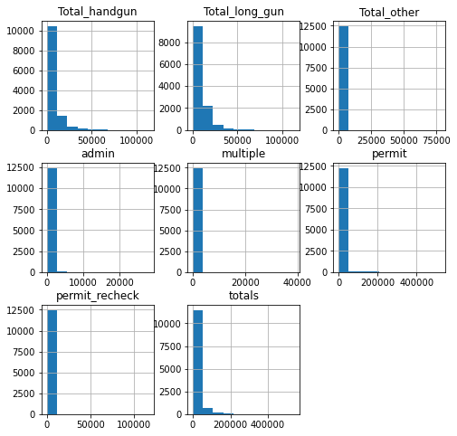

```python
df_gun.hist(figsize=(8,8));
```

### Research Question 2 Which states have had the highest growth in gun registrations?

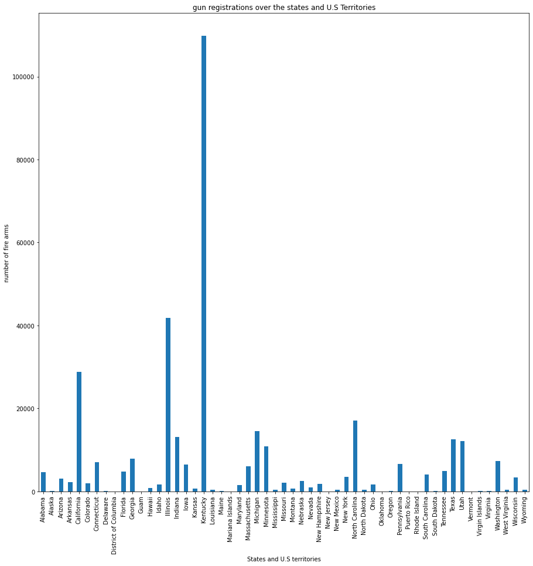

```python
ax = df_gun.groupby('state')['permit'].mean().plot(kind='bar',figsize=(15,15),title='gun registrations over the states and U.S Territories')
ax.set_xlabel("States and U.S territories")
ax.set_ylabel("number of fire arms")
```

#### from the last plot, the highest permited gun rate is 'Kentucky' state

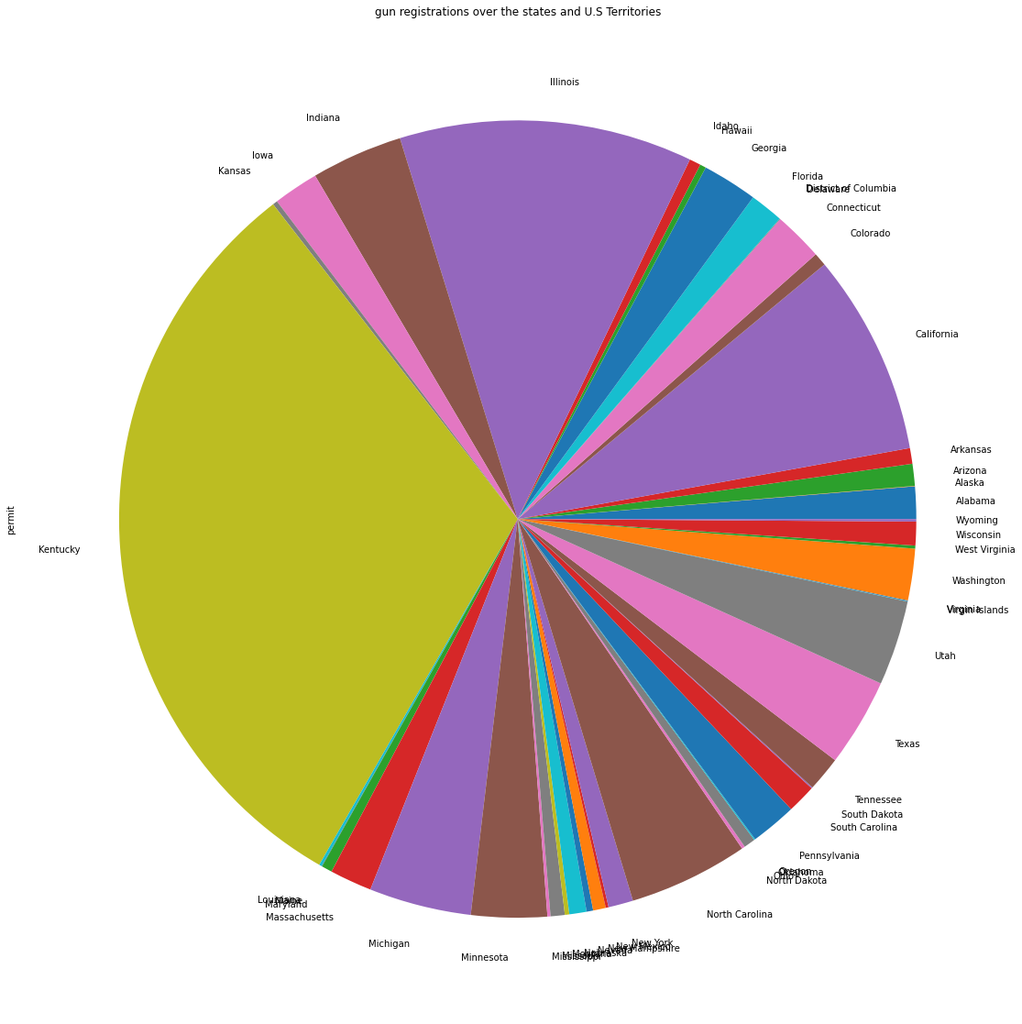

```python
# it will be easier with a pie plot to notice with
df_gun.groupby('state')['permit'].sum().plot(kind='pie',figsize=(20,20),title='gun registrations over the states and U.S Territories')
```

```python
#to get the number of permitted guns in kentucky
df_gun.groupby('state')['permit'].sum()['Kentucky']
```

```
24926779
```

### Research Question 3 What is the overall trend of gun purchases?

```python
df_gun.describe()[max]
```

```
count     12485.000000
mean      21595.725911
std       32591.418387
min           0.000000
25%        4638.000000
50%       12399.000000
75%       25453.000000
max      541978.000000
Name: totals, dtype: float64
```

```python
df_gun_purchases_trend = df_gun.groupby(['month'])['totals'].sum()
df_gun_purchases_trend
```

```
month
1998-11-01      21176
1998-12-01     870722
1999-01-01     585974
1999-02-01     690215
1999-03-01     741687
               ...
2017-05-01    1898840
2017-06-01    1888266
2017-07-01    1733308
2017-08-01    1896457
2017-09-01    1857226
Name: totals, Length: 227, dtype: int64
```

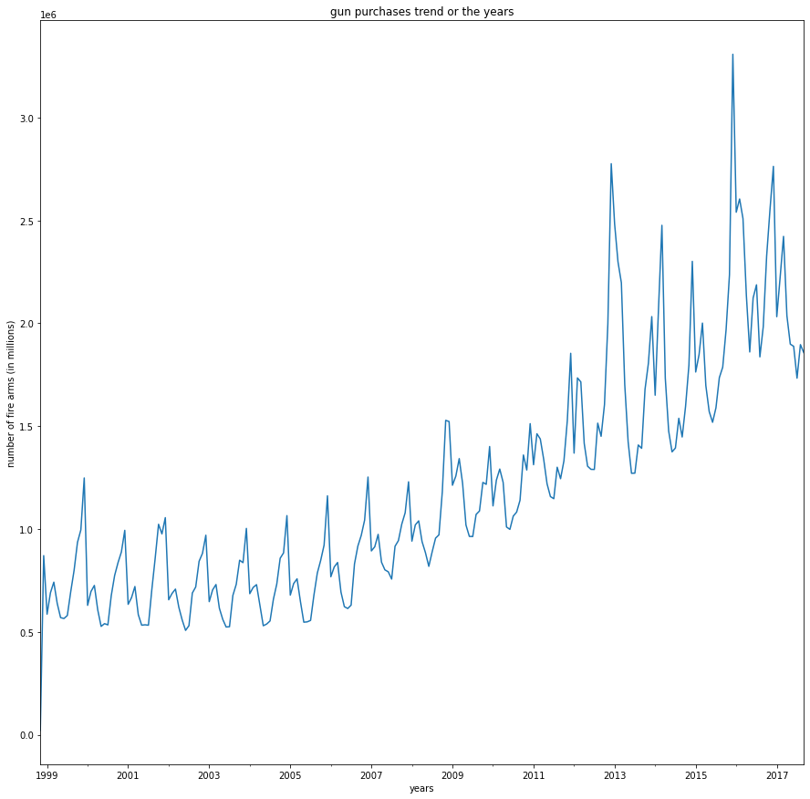

```python
ax=df_gun_purchases_trend.plot(x='month',y='totals',figsize= (15,15),title='gun purchases trend or the years')
ax.set_xlabel("years")
ax.set_ylabel("number of fire arms (in millions)")
```

#### Gun purchases trend increases regulary with spikes and the start of each year

### Research Question 4 Compare between the total gun purchases in the five US_territories?

```python
US_territories
```

```
['District of Columbia',
 'Guam',
 'Mariana Islands',
 'Puerto Rico',
 'Virgin Islands']
```

```python
df_US_territories = df_gun[df_gun['state'].isin(US_territories)]
df_US_territories
```

|  | month | state | permit | permit_recheck | multiple | admin | totals | Total_handgun | Total_long_gun | Total_other |
| --- | --- | --- | --- | --- | --- | --- | --- | --- | --- | --- |
| 8 | 2017-09-01 | District of Columbia | 1 | 0 | 0 | 0 | 61 | 56 | 4 | 0 |
| 11 | 2017-09-01 | Guam | 0 | 0 | 3 | 0 | 135 | 74 | 48 | 10 |
| 21 | 2017-09-01 | Mariana Islands | 0 | 0 | 1 | 0 | 16 | 12 | 3 | 0 |
| 41 | 2017-09-01 | Puerto Rico | 0 | 0 | 22 | 0 | 791 | 625 | 127 | 17 |
| 49 | 2017-09-01 | Virgin Islands | 1 | 0 | 0 | 0 | 9 | 6 | 2 | 0 |
| ... | ... | ... | ... | ... | ... | ... | ... | ... | ... | ... |
| 12438 | 1998-11-01 | District of Columbia | 0 | 0 | 0 | 0 | 0 | 0 | 0 | 0 |
| 12441 | 1998-11-01 | Guam | 0 | 0 | 0 | 0 | 0 | 0 | 0 | 0 |
| 12451 | 1998-11-01 | Mariana Islands | 0 | 0 | 0 | 0 | 0 | 0 | 0 | 0 |
| 12471 | 1998-11-01 | Puerto Rico | 0 | 0 | 0 | 0 | 2 | 1 | 1 | 0 |
| 12479 | 1998-11-01 | Virgin Islands | 0 | 0 | 0 | 0 | 0 | 0 | 0 | 0 |

1135 rows × 10 columns

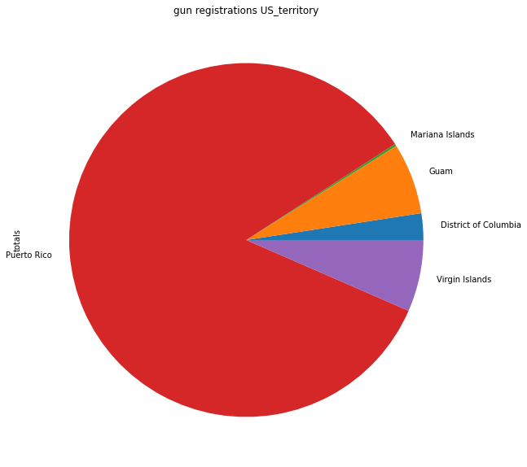

```python
# This pie chart clearfies the totals of ,title='gun registrations US_territory')
df_US_territories.groupby('state')['totals'].sum().plot(kind='pie',figsize=(10,10),title='gun registrations US_territory')
```

#### Puerto Rico Made the most Purchases

```python
df_US_territories.groupby('state')['totals'].sum()['Puerto Rico']
```

```
194464
```

### Research Question 5 Which US_territory has had the highest growth in gun registrations?

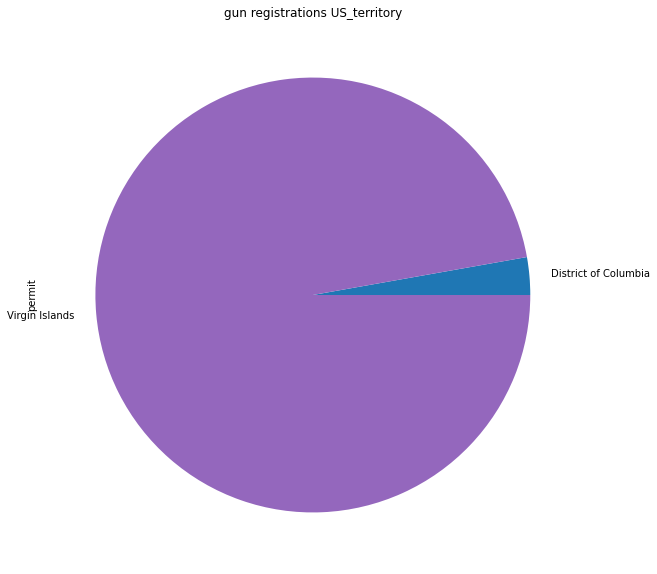

```python
df_US_territories.groupby('state')['permit'].sum().plot(kind='pie',figsize=(10,10),title='gun registrations US_territory')
```

```python
df_US_territories.groupby('state')['permit'].sum()
```

```
state
District of Columbia      330
Guam                        0
Mariana Islands             0
Puerto Rico                 0
Virgin Islands          11485
Name: permit, dtype: int32
```

```python
df_US_territories.groupby('state')['permit'].sum()['Virgin Islands']
```

```
11485
```

### Research Question 6 Which state had the highest total number of guns?

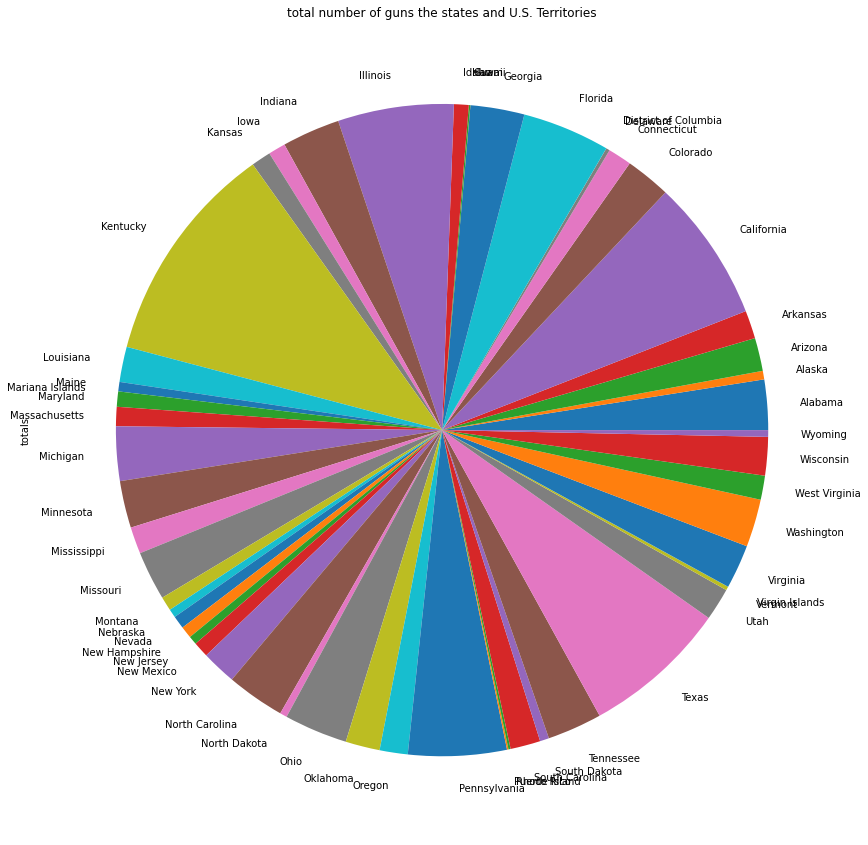

```python
df_gun.groupby('state')['totals'].sum().plot(kind='pie',figsize=(15,15),title='total number of guns the states and U.S. Territories')
```

#### Pie chart is so misleading in this case, so we will use the bar chart

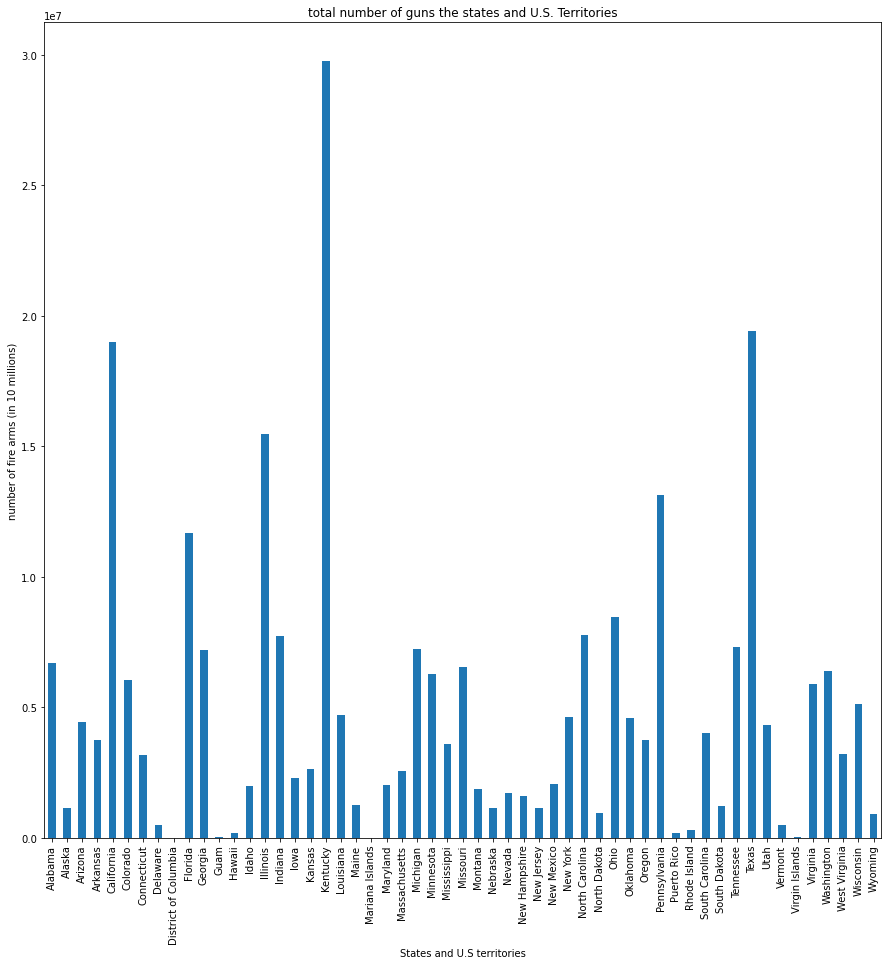

```python
ax = df_gun.groupby('state')['totals'].sum().plot(kind='bar',figsize=(15,15),title='total number of guns the states and U.S. Territories')
ax.set_xlabel("States and U.S territories")
ax.set_ylabel("number of fire arms (in 10 millions)")
```

#### The the bar chart choose that Kentaky state has the highest number of guns

```python
df_gun.groupby('state')['totals'].sum()['Kentucky']
```

```
29762434
```

### Research Question 7 Which states have was the highest at permit recheck?

[output not shown]

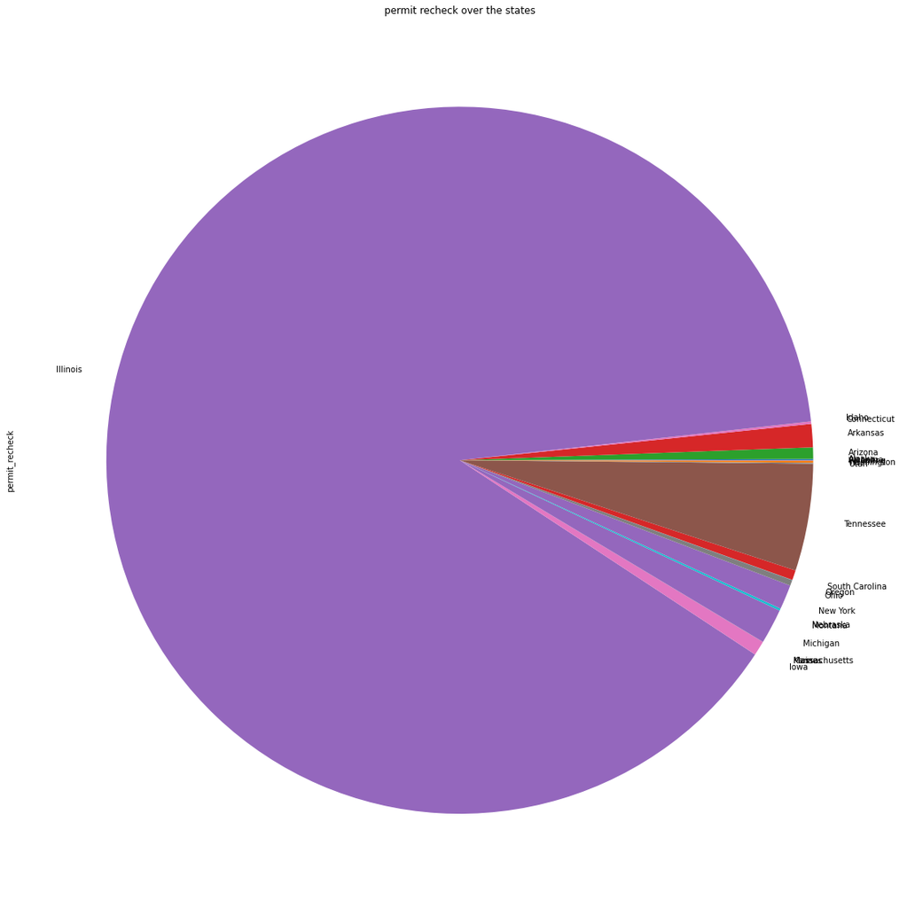

```python
df_gun.groupby('state')['permit_recheck'].sum().plot(kind='pie',figsize=(20,20),title='permit recheck over the states')
ax.set_xlabe
```

#### Most States doesn't have a single permit recheck, and the highes one is Illinois state

```python
df_gun.groupby('state')['permit_recheck'].sum()['Illinois']
```

[output not shown]

### Research Question 8 compare between the permit, permit recheck and totals ffor each state?

```python
ax = df_gun.groupby('state')['permit', 'permit_recheck' ,'totals'].sum().plot(kind='bar',figsize=(15,15))
ax.set_xlabel("States and U.S territories")
ax.set_ylabel("number of fire arms (in 10 millions)")
```

[output not shown]

### Research Question 9 Show the different gun types destripution over the states

```python
Total_Guns=['Total_handgun','Total_long_gun','Total_other']
ax=df_gun.groupby('state')[Total_Guns].sum().plot(kind='bar',figsize=(15,15),title='Different gun types destripution over the states')
ax.set_xlabel("States and U.S territories")
ax.set_ylabel("number of fire arms (in millions)")
```

[output not shown]

```python
df_gun.groupby('state')[Total_Guns].sum()
```

[output not shown]

## Conclusions

#### Most States doesn't have a single permit recheck, and the highes one is Illinois state

### Limitations

> They didn't specify the if the 'hadgun', 'long_gun', 'other' columns include all the the other same-gun-type related columns, it's very misleading, I summed up the same-gun-type related columns be ause the analysis didn't seem like to change by much and it seemed more reasonable to sum but they needed to clarify this point